# Identify_Customer_Segments

### Prerequsite - Upgrade Scikit Learn

The current workspace has scikit-learn v0.19.1 installed. However, you can upgrade scikit-learn to 0.24.x. and use this [OneHotEncoder](https://scikit-learn.org/0.21/modules/generated/sklearn.preprocessing.OneHotEncoder.html) library.

```python
!python -m pip install --upgrade scikit-learn
import sklearn
print('The scikit-learn version is {}.'.format(sklearn.__version__))
```

[output not shown]

```python
import os
os.environ['PATH'] = f"{os.environ['PATH']}:/root/.local/bin"
```

```python
# Now you can import and use OneHotEncoder
from sklearn.preprocessing import OneHotEncoder
# your code goes here
```

```python
# Similarly, should you need any other package, they can install it as:
!python -m pip install 'tensorflow-tensorboard<0.2.0,>=0.1.0'
```

```
    100% |████████████████████████████████| 1.6MB 5.4MB/s ta 0:00:011
```

# Project: Identify Customer Segments

In this project, you will apply unsupervised learning techniques to identify segments of the population that form the core customer base for a mail-order sales company in Germany. These segments can then be used to direct marketing campaigns towards audiences that will have the highest expected rate of returns. The data that you will use has been provided by our partners at Bertelsmann Arvato Analytics, and represents a real-life data science task.

This notebook will help you complete this task by providing a framework within which you will perform your analysis steps. In each step of the project, you will see some text describing the subtask that you will perform, followed by one or more code cells for you to complete your work. **Feel free to add additional code and markdown cells as you go along so that you can explore everything in precise chunks.** The code cells provided in the base template will outline only the major tasks, and will usually not be enough to cover all of the minor tasks that comprise it.

It should be noted that while there will be precise guidelines on how you should handle certain tasks in the project, there will also be places where an exact specification is not provided. **There will be times in the project where you will need to make and justify your own decisions on how to treat the data.** These are places where there may not be only one way to handle the data. In real-life tasks, there may be many valid ways to approach an analysis task. One of the most important things you can do is clearly document your approach so that other scientists can understand the decisions you've made.

At the end of most sections, there will be a Markdown cell labeled **Discussion**. In these cells, you will report your findings for the completed section, as well as document the decisions that you made in your approach to each subtask. **Your project will be evaluated not just on the code used to complete the tasks outlined, but also your communication about your observations and conclusions at each stage.**

```python
# import libraries here; add more as necessary
import numpy as np
import pandas as pd
import matplotlib.pyplot as plt
import seaborn as seaborn

# magic word for producing visualizations in notebook
%matplotlib inline

'''
Import note: The classroom currently uses sklearn version 0.19.
If you need to use an imputer, it is available in sklearn.preprocessing.Imputer,
instead of sklearn.impute as in newer versions of sklearn.
'''
pd.options.display.max_rows = None
pd.options.display.max_columns = None
```

### Step 0: Load the Data

Each row of the demographics files represents a single person, but also includes information outside of individuals, including information about their household, building, and neighborhood. You will use this information to cluster the general population into groups with similar demographic properties. Then, you will see how the people in the customers dataset fit into those created clusters. The hope here is that certain clusters are over-represented in the customers data, as compared to the general population; those over-represented clusters will be assumed to be part of the core userbase. This information can then be used for further applications, such as targeting for a marketing campaign.

To start off with, load in the demographics data for the general population into a pandas DataFrame, and do the same for the feature attributes summary. Note for all of the `.csv` data files in this project: they're semicolon (`;`) delimited, so you'll need an additional argument in your [`read_csv()`](https://pandas.pydata.org/pandas-docs/stable/generated/pandas.read_csv.html) call to read in the data properly. Also, considering the size of the main dataset, it may take some time for it to load completely.

Once the dataset is loaded, it's recommended that you take a little bit of time just browsing the general structure of the dataset and feature summary file. You'll be getting deep into the innards of the cleaning in the first major step of the project, so gaining some general familiarity can help you get your bearings.

```python
# Load data
azdias = pd.read_csv('Udacity_AZDIAS_Subset.csv', delimiter=';')
customers = pd.read_csv('Udacity_CUSTOMERS_Subset.csv', delimiter=';')
feat = pd.read_csv('AZDIAS_Feature_Summary.csv', delimiter=';')
```

```python
# Check the structure of the data after it's loaded (e.g. print the number of
azdias.head()
```

|  | AGER_TYP | ALTERSKATEGORIE_GROB | ANREDE_KZ | CJT_GESAMTTYP | FINANZ_MINIMALIST | FINANZ_SPARER | FINANZ_VORSORGER | FINANZ_ANLEGER | FINANZ_UNAUFFAELLIGER | FINANZ_HAUSBAUER | FINANZTYP | GEBURTSJAHR | GFK_URLAUBERTYP | GREEN_AVANTGARDE | HEALTH_TYP | LP_LEBENSPHASE_FEIN | LP_LEBENSPHASE_GROB | LP_FAMILIE_FEIN | LP_FAMILIE_GROB | LP_STATUS_FEIN | LP_STATUS_GROB | NATIONALITAET_KZ | PRAEGENDE_JUGENDJAHRE | RETOURTYP_BK_S | SEMIO_SOZ | SEMIO_FAM | SEMIO_REL | SEMIO_MAT | SEMIO_VERT | … |
| --- | --- | --- | --- | --- | --- | --- | --- | --- | --- | --- | --- | --- | --- | --- | --- | --- | --- | --- | --- | --- | --- | --- | --- | --- | --- | --- | --- | --- | --- | --- |
| 0 | -1 | 2 | 1 | 2.0 | 3 | 4 | 3 | 5 | 5 | 3 | 4 | 0 | 10.0 | 0 | -1 | 15.0 | 4.0 | 2.0 | 2.0 | 1.0 | 1.0 | 0 | 0 | 5.0 | 2 | 6 | 7 | 5 | 1 | … |
| 1 | -1 | 1 | 2 | 5.0 | 1 | 5 | 2 | 5 | 4 | 5 | 1 | 1996 | 10.0 | 0 | 3 | 21.0 | 6.0 | 5.0 | 3.0 | 2.0 | 1.0 | 1 | 14 | 1.0 | 5 | 4 | 4 | 3 | 1 | … |
| 2 | -1 | 3 | 2 | 3.0 | 1 | 4 | 1 | 2 | 3 | 5 | 1 | 1979 | 10.0 | 1 | 3 | 3.0 | 1.0 | 1.0 | 1.0 | 3.0 | 2.0 | 1 | 15 | 3.0 | 4 | 1 | 3 | 3 | 4 | … |
| 3 | 2 | 4 | 2 | 2.0 | 4 | 2 | 5 | 2 | 1 | 2 | 6 | 1957 | 1.0 | 0 | 2 | 0.0 | 0.0 | 0.0 | 0.0 | 9.0 | 4.0 | 1 | 8 | 2.0 | 5 | 1 | 2 | 1 | 4 | … |
| 4 | -1 | 3 | 1 | 5.0 | 4 | 3 | 4 | 1 | 3 | 2 | 5 | 1963 | 5.0 | 0 | 3 | 32.0 | 10.0 | 10.0 | 5.0 | 3.0 | 2.0 | 1 | 8 | 5.0 | 6 | 4 | 4 | 2 | 7 | … |

```python
customers.head()
```

|  | AGER_TYP | ALTERSKATEGORIE_GROB | ANREDE_KZ | CJT_GESAMTTYP | FINANZ_MINIMALIST | FINANZ_SPARER | FINANZ_VORSORGER | FINANZ_ANLEGER | FINANZ_UNAUFFAELLIGER | FINANZ_HAUSBAUER | FINANZTYP | GEBURTSJAHR | GFK_URLAUBERTYP | GREEN_AVANTGARDE | HEALTH_TYP | LP_LEBENSPHASE_FEIN | LP_LEBENSPHASE_GROB | LP_FAMILIE_FEIN | LP_FAMILIE_GROB | LP_STATUS_FEIN | LP_STATUS_GROB | NATIONALITAET_KZ | PRAEGENDE_JUGENDJAHRE | RETOURTYP_BK_S | SEMIO_SOZ | SEMIO_FAM | SEMIO_REL | SEMIO_MAT | SEMIO_VERT | … |
| --- | --- | --- | --- | --- | --- | --- | --- | --- | --- | --- | --- | --- | --- | --- | --- | --- | --- | --- | --- | --- | --- | --- | --- | --- | --- | --- | --- | --- | --- | --- |
| 0 | 2 | 4 | 1 | 5.0 | 5 | 1 | 5 | 1 | 2 | 2 | 2 | 0 | 4.0 | 1 | 1 | 20.0 | 5.0 | 2.0 | 2.0 | 10.0 | 5.0 | 1 | 4 | 5.0 | 6 | 5 | 2 | 6 | 6 | … |
| 1 | -1 | 4 | 1 | NaN | 5 | 1 | 5 | 1 | 3 | 2 | 2 | 0 | NaN | 0 | 1 | NaN | NaN | NaN | NaN | NaN | NaN | 1 | 0 | NaN | 3 | 6 | 2 | 6 | 7 | … |
| 2 | -1 | 4 | 2 | 2.0 | 5 | 1 | 5 | 1 | 4 | 4 | 2 | 0 | 3.0 | 1 | 2 | 13.0 | 3.0 | 1.0 | 1.0 | 10.0 | 5.0 | 1 | 4 | 5.0 | 2 | 2 | 1 | 3 | 3 | … |
| 3 | 1 | 4 | 1 | 2.0 | 5 | 1 | 5 | 2 | 1 | 2 | 6 | 0 | 10.0 | 0 | 2 | 0.0 | 0.0 | 0.0 | 0.0 | 9.0 | 4.0 | 1 | 1 | 3.0 | 6 | 5 | 3 | 4 | 7 | … |
| 4 | -1 | 3 | 1 | 6.0 | 3 | 1 | 4 | 4 | 5 | 2 | 2 | 1960 | 2.0 | 0 | 3 | 31.0 | 10.0 | 10.0 | 5.0 | 1.0 | 1.0 | 1 | 8 | 5.0 | 4 | 5 | 4 | 6 | 5 | … |

> **Tip**: Add additional cells to keep everything in reasonably-sized chunks! Keyboard shortcut `esc --> a` (press escape to enter command mode, then press the 'A' key) adds a new cell before the active cell, and `esc --> b` adds a new cell after the active cell. If you need to convert an active cell to a markdown cell, use `esc --> m` and to convert to a code cell, use `esc --> y`.

## Step 1: Preprocessing

### Step 1.1: Assess Missing Data

The feature summary file contains a summary of properties for each demographics data column. You will use this file to help you make cleaning decisions during this stage of the project. First of all, you should assess the demographics data in terms of missing data. Pay attention to the following points as you perform your analysis, and take notes on what you observe. Make sure that you fill in the **Discussion** cell with your findings and decisions at the end of each step that has one!

#### Step 1.1.1: Convert Missing Value Codes to NaNs

The fourth column of the feature attributes summary (loaded in above as `feat_info`) documents the codes from the data dictionary that indicate missing or unknown data. While the file encodes this as a list (e.g. `[-1,0]`), this will get read in as a string object. You'll need to do a little bit of parsing to make use of it to identify and clean the data. Convert data that matches a 'missing' or 'unknown' value code into a numpy NaN value. You might want to see how much data takes on a 'missing' or 'unknown' code, and how much data is naturally missing, as a point of interest.

**As one more reminder, you are encouraged to add additional cells to break up your analysis into manageable chunks.**

```python
# How many NaN before the assessment
nan_count_before = azdias.isna().sum().sum()
nan_count_before

# Should be 4896838
```

[output not shown]

```python
# azdias.head()
feat.head()
```

|  | attribute | information_level | type | missing_or_unknown |
| --- | --- | --- | --- | --- |
| 0 | AGER_TYP | person | categorical | [-1,0] |
| 1 | ALTERSKATEGORIE_GROB | person | ordinal | [-1,0,9] |
| 2 | ANREDE_KZ | person | categorical | [-1,0] |
| 3 | CJT_GESAMTTYP | person | categorical | [0] |
| 4 | FINANZ_MINIMALIST | person | ordinal | [-1] |

```python
for i, f in feat.iterrows():
    tobeNah = f['missing_or_unknown']
    tobeNah = tobeNah.strip('[').strip(']').split(',')
    for val in tobeNah:
        try:
            val = int(val)
        except ValueError:
            pass # If val is not a number, keep it
        azdias[f['attribute']] = azdias[f['attribute']].replace(val, np.nan)

azdias.head()
```

|  | AGER_TYP | ALTERSKATEGORIE_GROB | ANREDE_KZ | CJT_GESAMTTYP | FINANZ_MINIMALIST | FINANZ_SPARER | FINANZ_VORSORGER | FINANZ_ANLEGER | FINANZ_UNAUFFAELLIGER | FINANZ_HAUSBAUER | FINANZTYP | GEBURTSJAHR | GFK_URLAUBERTYP | GREEN_AVANTGARDE | HEALTH_TYP | LP_LEBENSPHASE_FEIN | LP_LEBENSPHASE_GROB | LP_FAMILIE_FEIN | LP_FAMILIE_GROB | LP_STATUS_FEIN | LP_STATUS_GROB | NATIONALITAET_KZ | PRAEGENDE_JUGENDJAHRE | RETOURTYP_BK_S | SEMIO_SOZ | SEMIO_FAM | SEMIO_REL | SEMIO_MAT | SEMIO_VERT | … |
| --- | --- | --- | --- | --- | --- | --- | --- | --- | --- | --- | --- | --- | --- | --- | --- | --- | --- | --- | --- | --- | --- | --- | --- | --- | --- | --- | --- | --- | --- | --- |
| 0 | NaN | 2.0 | 1 | 2.0 | 3 | 4 | 3 | 5 | 5 | 3 | 4 | NaN | 10.0 | 0 | NaN | 15.0 | 4.0 | 2.0 | 2.0 | 1.0 | 1.0 | NaN | NaN | 5.0 | 2 | 6 | 7 | 5 | 1 | … |
| 1 | NaN | 1.0 | 2 | 5.0 | 1 | 5 | 2 | 5 | 4 | 5 | 1 | 1996.0 | 10.0 | 0 | 3.0 | 21.0 | 6.0 | 5.0 | 3.0 | 2.0 | 1.0 | 1.0 | 14.0 | 1.0 | 5 | 4 | 4 | 3 | 1 | … |
| 2 | NaN | 3.0 | 2 | 3.0 | 1 | 4 | 1 | 2 | 3 | 5 | 1 | 1979.0 | 10.0 | 1 | 3.0 | 3.0 | 1.0 | 1.0 | 1.0 | 3.0 | 2.0 | 1.0 | 15.0 | 3.0 | 4 | 1 | 3 | 3 | 4 | … |
| 3 | 2.0 | 4.0 | 2 | 2.0 | 4 | 2 | 5 | 2 | 1 | 2 | 6 | 1957.0 | 1.0 | 0 | 2.0 | NaN | NaN | NaN | NaN | 9.0 | 4.0 | 1.0 | 8.0 | 2.0 | 5 | 1 | 2 | 1 | 4 | … |
| 4 | NaN | 3.0 | 1 | 5.0 | 4 | 3 | 4 | 1 | 3 | 2 | 5 | 1963.0 | 5.0 | 0 | 3.0 | 32.0 | 10.0 | 10.0 | 5.0 | 3.0 | 2.0 | 1.0 | 8.0 | 5.0 | 6 | 4 | 4 | 2 | 7 | … |

```python
nan_count_after = azdias.isna().sum().sum()
print(f"NaN count: Before {nan_count_before}, after {nan_count_after}")
```

[output not shown]

#### Step 1.1.2: Assess Missing Data in Each Column

How much missing data is present in each column? There are a few columns that are outliers in terms of the proportion of values that are missing. You will want to use matplotlib's [`hist()`](https://matplotlib.org/api/_as_gen/matplotlib.pyplot.hist.html) function to visualize the distribution of missing value counts to find these columns. Identify and document these columns. While some of these columns might have justifications for keeping or re-encoding the data, for this project you should just remove them from the dataframe. (Feel free to make remarks about these outlier columns in the discussion, however!)

For the remaining features, are there any patterns in which columns have, or share, missing data?

```python
# Perform an assessment of how much missing data there is in each column of the dataset.
azdias_count = azdias.shape[0]
azdias_nan_percent = azdias.isna().sum()/azdias_count
azdias_nan_percent.head()
# If the value is too hidh, the column is not meaningful for the calculation
# We can be remove those columns
```

```
AGER_TYP                0.769554
ALTERSKATEGORIE_GROB    0.003233
ANREDE_KZ               0.000000
CJT_GESAMTTYP           0.005446
FINANZ_MINIMALIST       0.000000
dtype: float64
```

```python
def showMissingData(dat, title, xLabel, yLabel):
    plt.figure(figsize=(20,10))
    plt.hist(dat)
    plt.title(title)
    plt.xlabel(xLabel)
    plt.ylabel(yLabel)
    plt.grid()
    plt.show()
```

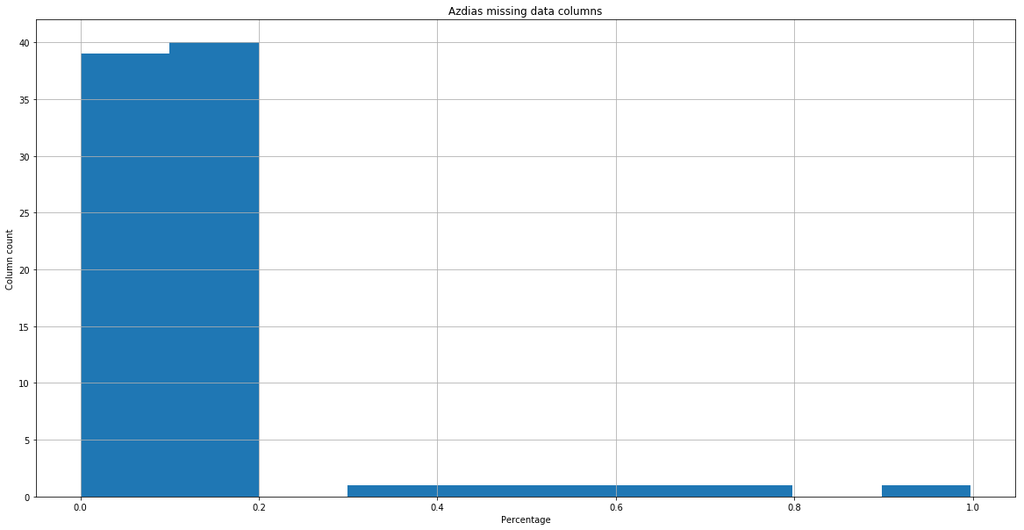

```python
# Investigate patterns in the amount of missing data in each column.
showMissingData(
    azdias_nan_percent,
    'Azdias missing data columns',
    'Percentage',
    'Column count')
```

```python
# Remove the outlier columns from the dataset. (You'll perform other data
# engineering tasks such as re-encoding and imputation later.)

azdias_nan_tobe_removed_threshold = 0.2 # Based on the above result
azdias_nan_tobe_removed = azdias_nan_percent[azdias_nan_percent > azdias_nan_tobe_removed_threshold]
azdias_nan_tobe_removed
```

```
AGER_TYP        0.769554
GEBURTSJAHR     0.440203
TITEL_KZ        0.997576
ALTER_HH        0.348137
KK_KUNDENTYP    0.655967
KBA05_BAUMAX    0.534687
dtype: float64
```

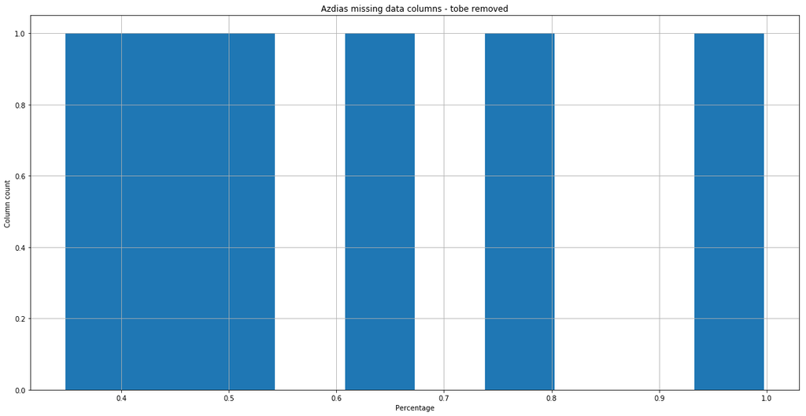

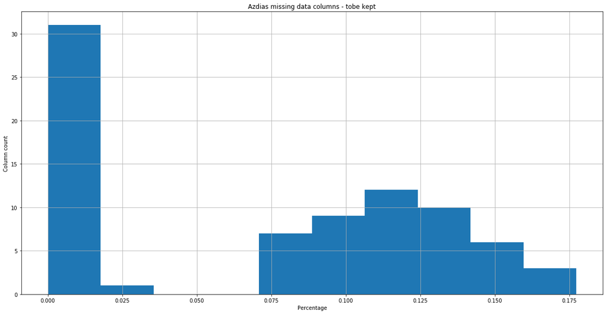

```python
# Investigate patterns in the amount of missing data in each column.
showMissingData(
    azdias_nan_percent[azdias_nan_percent > azdias_nan_tobe_removed_threshold], # To be kept columns
    'Azdias missing data columns - tobe removed',
    'Percentage',
    'Column count')
showMissingData(
    azdias_nan_percent[azdias_nan_percent <= azdias_nan_tobe_removed_threshold], # To be kept columns
    'Azdias missing data columns - tobe kept',
    'Percentage',
    'Column count')
```

```python
#Drop column
azdias.drop(azdias_nan_tobe_removed.index, axis=1, inplace=True)
azdias.head()
```

|  | ALTERSKATEGORIE_GROB | ANREDE_KZ | CJT_GESAMTTYP | FINANZ_MINIMALIST | FINANZ_SPARER | FINANZ_VORSORGER | FINANZ_ANLEGER | FINANZ_UNAUFFAELLIGER | FINANZ_HAUSBAUER | FINANZTYP | GFK_URLAUBERTYP | GREEN_AVANTGARDE | HEALTH_TYP | LP_LEBENSPHASE_FEIN | LP_LEBENSPHASE_GROB | LP_FAMILIE_FEIN | LP_FAMILIE_GROB | LP_STATUS_FEIN | LP_STATUS_GROB | NATIONALITAET_KZ | PRAEGENDE_JUGENDJAHRE | RETOURTYP_BK_S | SEMIO_SOZ | SEMIO_FAM | SEMIO_REL | SEMIO_MAT | SEMIO_VERT | SEMIO_LUST | SEMIO_ERL | … |
| --- | --- | --- | --- | --- | --- | --- | --- | --- | --- | --- | --- | --- | --- | --- | --- | --- | --- | --- | --- | --- | --- | --- | --- | --- | --- | --- | --- | --- | --- | --- |
| 0 | 2.0 | 1 | 2.0 | 3 | 4 | 3 | 5 | 5 | 3 | 4 | 10.0 | 0 | NaN | 15.0 | 4.0 | 2.0 | 2.0 | 1.0 | 1.0 | NaN | NaN | 5.0 | 2 | 6 | 7 | 5 | 1 | 5 | 3 | … |
| 1 | 1.0 | 2 | 5.0 | 1 | 5 | 2 | 5 | 4 | 5 | 1 | 10.0 | 0 | 3.0 | 21.0 | 6.0 | 5.0 | 3.0 | 2.0 | 1.0 | 1.0 | 14.0 | 1.0 | 5 | 4 | 4 | 3 | 1 | 2 | 2 | … |
| 2 | 3.0 | 2 | 3.0 | 1 | 4 | 1 | 2 | 3 | 5 | 1 | 10.0 | 1 | 3.0 | 3.0 | 1.0 | 1.0 | 1.0 | 3.0 | 2.0 | 1.0 | 15.0 | 3.0 | 4 | 1 | 3 | 3 | 4 | 4 | 6 | … |
| 3 | 4.0 | 2 | 2.0 | 4 | 2 | 5 | 2 | 1 | 2 | 6 | 1.0 | 0 | 2.0 | NaN | NaN | NaN | NaN | 9.0 | 4.0 | 1.0 | 8.0 | 2.0 | 5 | 1 | 2 | 1 | 4 | 4 | 7 | … |
| 4 | 3.0 | 1 | 5.0 | 4 | 3 | 4 | 1 | 3 | 2 | 5 | 5.0 | 0 | 3.0 | 32.0 | 10.0 | 10.0 | 5.0 | 3.0 | 2.0 | 1.0 | 8.0 | 5.0 | 6 | 4 | 4 | 2 | 7 | 4 | 4 | … |

#### Discussion 1.1.2: Assess Missing Data in Each Column

(Double click this cell and replace this text with your own text, reporting your observations regarding the amount of missing data in each column. Are there any patterns in missing values? Which columns were removed from the dataset?)

#### Answer

- AGER_TYP 0.769554
- GEBURTSJAHR 0.440203
- TITEL_KZ 0.997576
- ALTER_HH 0.348137
- KK_KUNDENTYP 0.655967
- KBA05_BAUMAX 0.534687

#### Step 1.1.3: Assess Missing Data in Each Row

Now, you'll perform a similar assessment for the rows of the dataset. How much data is missing in each row? As with the columns, you should see some groups of points that have a very different numbers of missing values. Divide the data into two subsets: one for data points that are above some threshold for missing values, and a second subset for points below that threshold.

In order to know what to do with the outlier rows, we should see if the distribution of data values on columns that are not missing data (or are missing very little data) are similar or different between the two groups. Select at least five of these columns and compare the distribution of values.

- You can use seaborn's [`countplot()`](https://seaborn.pydata.org/generated/seaborn.countplot.html) function to create a bar chart of code frequencies and matplotlib's [`subplot()`](https://matplotlib.org/api/_as_gen/matplotlib.pyplot.subplot.html) function to put bar charts for the two subplots side by side.
- To reduce repeated code, you might want to write a function that can perform this comparison, taking as one of its arguments a column to be compared.

Depending on what you observe in your comparison, this will have implications on how you approach your conclusions later in the analysis. If the distributions of non-missing features look similar between the data with many missing values and the data with few or no missing values, then we could argue that simply dropping those points from the analysis won't present a major issue. On the other hand, if the data with many missing values looks very different from the data with few or no missing values, then we should make a note on those data as special. We'll revisit these data later on. **Either way, you should continue your analysis for now using just the subset of the data with few or no missing values.**

```python
# How much data is missing in each row of the dataset?
azdias_nan_rows_percent = azdias.isna().sum(axis=1)/azdias.shape[1]
azdias_nan_rows_percent.head()
```

```
0    0.544304
1    0.000000
2    0.000000
3    0.088608
4    0.000000
dtype: float64
```

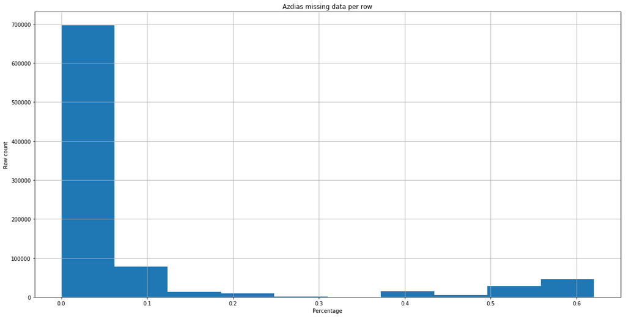

```python
showMissingData(
    azdias_nan_rows_percent,
    'Azdias missing data per row',
    'Percentage',
    'Row count')
```

```python
# Write code to divide the data into two subsets based on the number of missing
# values in each row.
azdias_nan_rows_tobe_removed_threshold = 0.35 # Based on the above result
low_missing_rows = azdias.loc[azdias_nan_rows_percent[azdias_nan_rows_percent < azdias_nan_rows_tobe_removed_threshold].index]
high_missing_rows = azdias.loc[azdias_nan_rows_percent[azdias_nan_rows_percent > azdias_nan_rows_tobe_removed_threshold].index]

# Print the data
low_missing_rows.shape, high_missing_rows.shape
```

```
((798044, 79), (93177, 79))
```

```python
# Compare the distribution of values for at least five columns
# where there are no or few missing values, between the two subsets.

azdias_nan = azdias.isna().sum()
azdias_nan_top_filled_10_cols = azdias_nan.sort_values().index[:10]
azdias_nan_top_filled_10 = azdias[azdias_nan_top_filled_10_cols]
azdias_nan_top_filled_10.head()
```

|  | ZABEOTYP | SEMIO_REL | SEMIO_MAT | SEMIO_VERT | SEMIO_LUST | SEMIO_ERL | SEMIO_KULT | SEMIO_RAT | SEMIO_KRIT | SEMIO_DOM |
| --- | --- | --- | --- | --- | --- | --- | --- | --- | --- | --- |
| 0 | 3 | 7 | 5 | 1 | 5 | 3 | 3 | 4 | 7 | 6 |
| 1 | 5 | 4 | 3 | 1 | 2 | 2 | 3 | 6 | 4 | 7 |
| 2 | 5 | 3 | 3 | 4 | 4 | 6 | 3 | 4 | 7 | 7 |
| 3 | 3 | 2 | 1 | 4 | 4 | 7 | 4 | 3 | 4 | 4 |
| 4 | 4 | 4 | 2 | 7 | 4 | 4 | 6 | 2 | 3 | 2 |

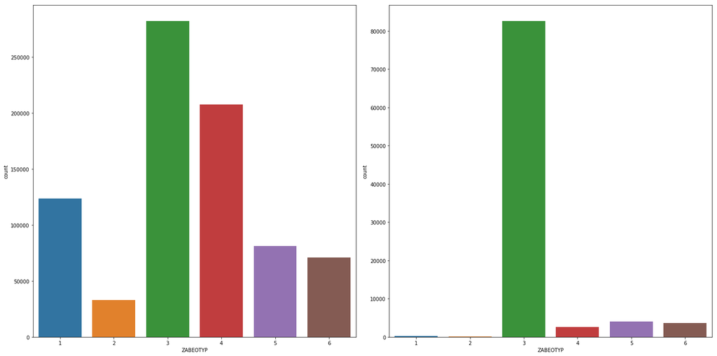

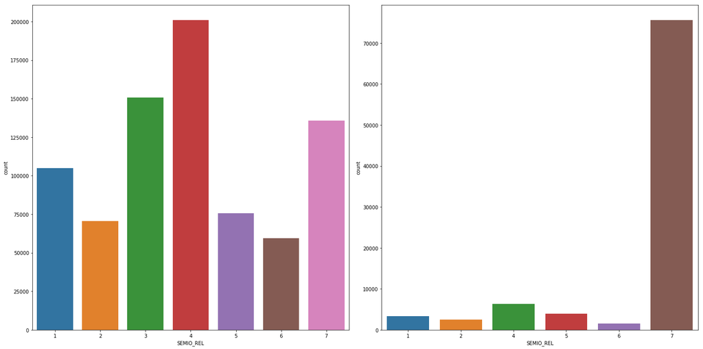

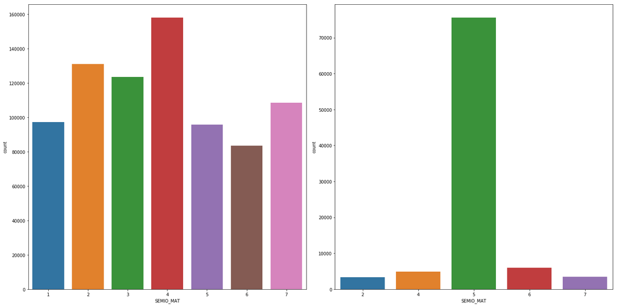

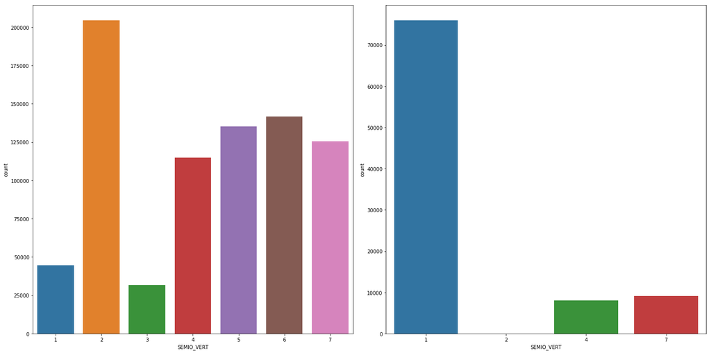

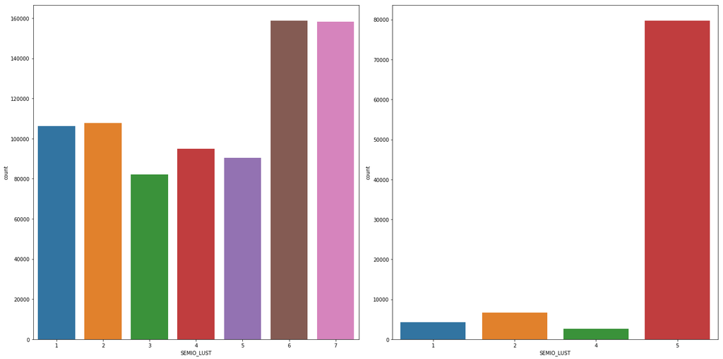

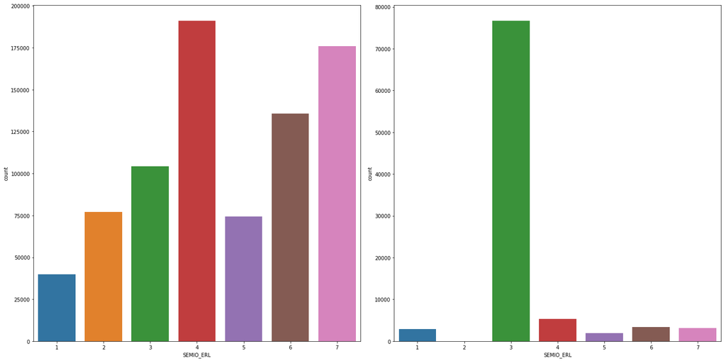

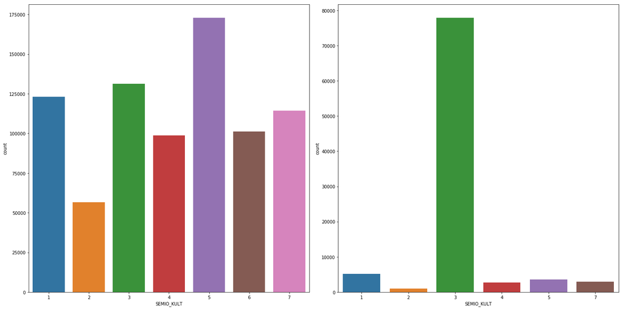

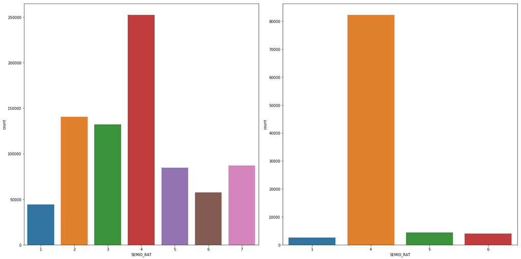

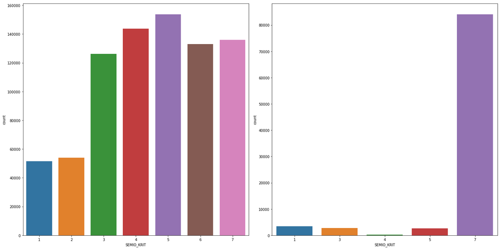

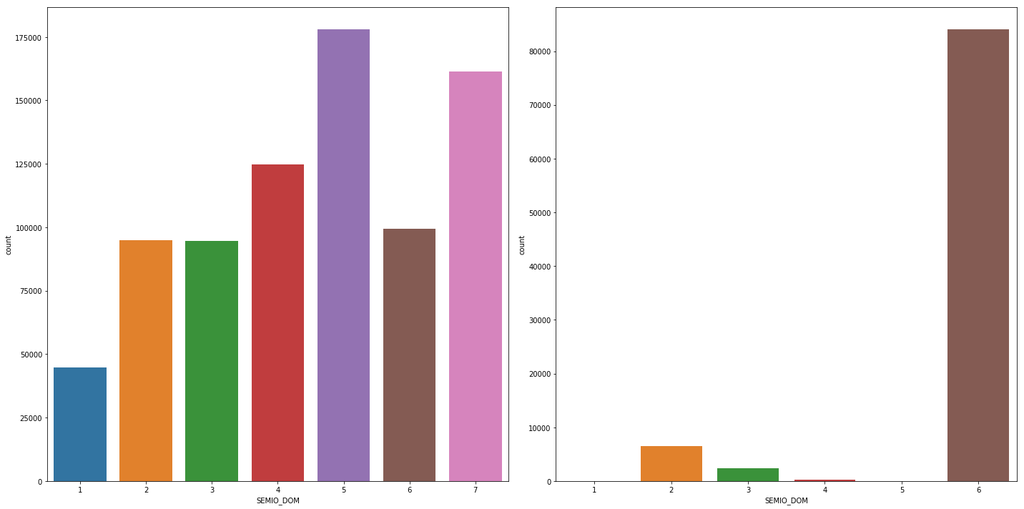

```python
# Compare 10 columns
for c in azdias_nan_top_filled_10:
    f, plots = plt.subplots(1, 2, figsize=(20, 10))
    seaborn.countplot(x=c, data=low_missing_rows, ax=plots[0])
    seaborn.countplot(x=c, data=high_missing_rows, ax=plots[1])
    f.tight_layout()
```

### Step 1.2: Select and Re-Encode Features

Checking for missing data isn't the only way in which you can prepare a dataset for analysis. Since the unsupervised learning techniques to be used will only work on data that is encoded numerically, you need to make a few encoding changes or additional assumptions to be able to make progress. In addition, while almost all of the values in the dataset are encoded using numbers, not all of them represent numeric values. Check the third column of the feature summary (`feat_info`) for a summary of types of measurement.

- For numeric and interval data, these features can be kept without changes.
- Most of the variables in the dataset are ordinal in nature. While ordinal values may technically be non-linear in spacing, make the simplifying assumption that the ordinal variables can be treated as being interval in nature (that is, kept without any changes).
- Special handling may be necessary for the remaining two variable types: categorical, and 'mixed'.

In the first two parts of this sub-step, you will perform an investigation of the categorical and mixed-type features and make a decision on each of them, whether you will keep, drop, or re-encode each. Then, in the last part, you will create a new data frame with only the selected and engineered columns.

Data wrangling is often the trickiest part of the data analysis process, and there's a lot of it to be done here. But stick with it: once you're done with this step, you'll be ready to get to the machine learning parts of the project!

```python
# How many features are there of each data type?
feat.type.value_counts()

# Should be as below
# ordinal        49
# categorical    21
# mixed           7
# numeric         7
# interval        1
```

```
ordinal        49
categorical    21
numeric         7
mixed           7
interval        1
Name: type, dtype: int64
```

#### Step 1.2.1: Re-Encode Categorical Features

For categorical data, you would ordinarily need to encode the levels as dummy variables. Depending on the number of categories, perform one of the following:

- For binary (two-level) categoricals that take numeric values, you can keep them without needing to do anything.
- There is one binary variable that takes on non-numeric values. For this one, you need to re-encode the values as numbers or create a dummy variable.
- For multi-level categoricals (three or more values), you can choose to encode the values using multiple dummy variables (e.g. via [OneHotEncoder](http://scikit-learn.org/stable/modules/generated/sklearn.preprocessing.OneHotEncoder.html)), or (to keep things straightforward) just drop them from the analysis. As always, document your choices in the Discussion section.

```python
feat_categorical_data = feat[feat['type']=='categorical']
# feat_categorical_data
feat_categorical_data.attribute[:10]
```

```
0             AGER_TYP
2            ANREDE_KZ
3        CJT_GESAMTTYP
10           FINANZTYP
12     GFK_URLAUBERTYP
13    GREEN_AVANTGARDE
17     LP_FAMILIE_FEIN
18     LP_FAMILIE_GROB
19      LP_STATUS_FEIN
20      LP_STATUS_GROB
Name: attribute, dtype: object
```

```python
# Assess categorical variables: which are binary, which are multi-level, and
# which one needs to be re-encoded?
binary_categorical_attrs = []
non_binary_categorical_attrs = []
for attr in feat_categorical_data.attribute:
    if attr not in low_missing_rows.columns:
        continue
    attr_values = low_missing_rows[attr].unique()
    attr_values_count = low_missing_rows[attr].nunique()
    if attr_values_count == 2:
        binary_categorical_attrs.append(attr)
        print(f"Column {attr} has {attr_values_count} values: {attr_values}")
    else:
        non_binary_categorical_attrs.append(attr)
print(f"We will remove these columns: {non_binary_categorical_attrs}")
```

```
Column ANREDE_KZ has 2 values: [2 1]
Column GREEN_AVANTGARDE has 2 values: [0 1]
Column SOHO_KZ has 2 values: [1. 0.]
Column VERS_TYP has 2 values: [ 2.  1. nan]
Column OST_WEST_KZ has 2 values: ['W' 'O']
We will remove these columns: ['CJT_GESAMTTYP', 'FINANZTYP', 'GFK_URLAUBERTYP', 'LP_FAMILIE_FEIN', 'LP_FAMILIE_GROB', 'LP_STATUS_FEIN', 'LP_STATUS_GROB', 'NATIONALITAET_KZ', 'SHOPPER_TYP', 'ZABEOTYP', 'GEBAEUDETYP', 'CAMEO_DEUG_2015', 'CAMEO_DEU_2015']
```

```python
# Re-encode categorical variable(s) to be kept in the analysis.
try:
    low_missing_rows.drop(non_binary_categorical_attrs, axis=1, inplace=True)
except:
    pass # To run multiple time
try:
    low_missing_rows['OST_WEST_KZ'] = low_missing_rows['OST_WEST_KZ'].replace({'W': 1, 'O': 0})
except:
    pass # To run multiple time
```

#### Discussion 1.2.1: Re-Encode Categorical Features

(Double-click this cell and replace this text with your own text, reporting your findings and decisions regarding categorical features. Which ones did you keep, which did you drop, and what engineering steps did you perform?)

#### Answer

As the coumn OST_WEST_KZ have 2 values W and O, it's the simpliest to encode them to 0 and 1 The multi-level is not meaningful for clustering, so I decided to remove it

#### Step 1.2.2: Engineer Mixed-Type Features

There are a handful of features that are marked as "mixed" in the feature summary that require special treatment in order to be included in the analysis. There are two in particular that deserve attention; the handling of the rest are up to your own choices:

- "PRAEGENDE_JUGENDJAHRE" combines information on three dimensions: generation by decade, movement (mainstream vs. avantgarde), and nation (east vs. west). While there aren't enough levels to disentangle east from west, you should create two new variables to capture the other two dimensions: an interval-type variable for decade, and a binary variable for movement.
- "CAMEO_INTL_2015" combines information on two axes: wealth and life stage. Break up the two-digit codes by their 'tens'-place and 'ones'-place digits into two new ordinal variables (which, for the purposes of this project, is equivalent to just treating them as their raw numeric values).
- If you decide to keep or engineer new features around the other mixed-type features, make sure you note your steps in the Discussion section.

Be sure to check `Data_Dictionary.md` for the details needed to finish these tasks.

```python
# from IPython.display import Markdown, display
# with open('Data_Dictionary.md', 'r') as file:
#     data_dict_md = file.read()
# display(Markdown(data_dict_md))
```

```python
# feat.type.value_counts()
feat_mixed_data = feat[feat['type']=='mixed']
feat_mixed_data.attribute
```

```
15      LP_LEBENSPHASE_FEIN
16      LP_LEBENSPHASE_GROB
22    PRAEGENDE_JUGENDJAHRE
56                 WOHNLAGE
59          CAMEO_INTL_2015
64             KBA05_BAUMAX
79              PLZ8_BAUMAX
Name: attribute, dtype: object
```

```python
for attr in feat_mixed_data.attribute:
    if attr not in low_missing_rows.columns:
        continue
    attr_values = low_missing_rows[attr].unique()
    attr_values_count = low_missing_rows[attr].nunique()
    print(f"==> Column {attr} has {attr_values_count} values: {attr_values}\n")
```

```
==> Column LP_LEBENSPHASE_FEIN has 40 values: [21.  3. nan 32.  8.  2.  5. 10.  4.  6. 23. 12. 20.  1. 11. 25. 13. 18.
 31. 38. 35. 30.  7. 22. 14. 29. 24. 28. 37. 26. 39. 27. 36.  9. 34. 33.
 15. 40. 16. 19. 17.]

==> Column LP_LEBENSPHASE_GROB has 12 values: [ 6.  1. nan 10.  2.  3.  5.  7. 12. 11.  9.  4.  8.]

==> Column PRAEGENDE_JUGENDJAHRE has 15 values: [14. 15.  8.  3. 10. 11.  5.  9.  6.  4. nan  2.  1. 12. 13.  7.]

==> Column WOHNLAGE has 8 values: [4. 2. 7. 3. 5. 1. 8. 0.]

==> Column CAMEO_INTL_2015 has 21 values: ['51' '24' '12' '43' '54' '22' '14' '13' '15' '33' '41' '34' '55' nan '25'
 '23' '31' '52' '35' '45' '44' '32']

==> Column PLZ8_BAUMAX has 5 values: [ 1.  2. nan  4.  5.  3.]
```

### 1.18. PRAEGENDE_JUGENDJAHRE

Dominating movement of person's youth (avantgarde vs. mainstream; east vs. west)

- -1: unknown
- 0: unknown
- 1: 40s - war years (Mainstream, E+W)
- 2: 40s - reconstruction years (Avantgarde, E+W)
- 3: 50s - economic miracle (Mainstream, E+W)
- 4: 50s - milk bar / Individualisation (Avantgarde, E+W)
- 5: 60s - economic miracle (Mainstream, E+W)
- 6: 60s - generation 68 / student protestors (Avantgarde, W)
- 7: 60s - opponents to the building of the Wall (Avantgarde, E)
- 8: 70s - family orientation (Mainstream, E+W)
- 9: 70s - peace movement (Avantgarde, E+W)
- 10: 80s - Generation Golf (Mainstream, W)
- 11: 80s - ecological awareness (Avantgarde, W)
- 12: 80s - FDJ / communist party youth organisation (Mainstream, E)
- 13: 80s - Swords into ploughshares (Avantgarde, E)
- 14: 90s - digital media kids (Mainstream, E+W)
- 15: 90s - ecological awareness (Avantgarde, E+W)

```python
# Investigate "PRAEGENDE_JUGENDJAHRE" and engineer two new variables.
# Movement: 0: mainstream, 1: avantgarde
# Generation: Using numbers accordingly
movements = {1:0, 2:1, 3:0, 4:1, 5:0, 6:1, 7:1, 8:0, 9:1, 10:0, 11:1, 12:0, 13:1, 14:0, 15:1}
generations = {1:40, 2:40, 3:50, 4:50, 5:60, 6:60, 7:60, 8:70, 9:70, 10:80, 11:80, 12:80, 13:80, 14:90, 15:90}
low_missing_rows['Movement'] = low_missing_rows['PRAEGENDE_JUGENDJAHRE'].apply(
    lambda x: np.nan if np.isnan(x) else movements[x])
low_missing_rows['Generation'] = low_missing_rows['PRAEGENDE_JUGENDJAHRE'].apply(
    lambda x: np.nan if np.isnan(x) else generations[x])

low_missing_rows[['PRAEGENDE_JUGENDJAHRE', 'Movement', 'Generation']].head()
```

|  | PRAEGENDE_JUGENDJAHRE | Movement | Generation |
| --- | --- | --- | --- |
| 1 | 14.0 | 0.0 | 90.0 |
| 2 | 15.0 | 1.0 | 90.0 |
| 3 | 8.0 | 0.0 | 70.0 |
| 4 | 8.0 | 0.0 | 70.0 |
| 5 | 3.0 | 0.0 | 50.0 |

### 4.3. CAMEO_INTL_2015

German CAMEO: Wealth / Life Stage Typology, mapped to international code

- -1: unknown
- 11: Wealthy Households - Pre-Family Couples & Singles
- 12: Wealthy Households - Young Couples With Children
- 13: Wealthy Households - Families With School Age Children
- 14: Wealthy Households - Older Families & Mature Couples
- 15: Wealthy Households - Elders In Retirement
- 21: Prosperous Households - Pre-Family Couples & Singles
- 22: Prosperous Households - Young Couples With Children
- 23: Prosperous Households - Families With School Age Children
- 24: Prosperous Households - Older Families & Mature Couples
- 25: Prosperous Households - Elders In Retirement
- 31: Comfortable Households - Pre-Family Couples & Singles
- 32: Comfortable Households - Young Couples With Children
- 33: Comfortable Households - Families With School Age Children
- 34: Comfortable Households - Older Families & Mature Couples
- 35: Comfortable Households - Elders In Retirement
- 41: Less Affluent Households - Pre-Family Couples & Singles
- 42: Less Affluent Households - Young Couples With Children
- 43: Less Affluent Households - Families With School Age Children
- 44: Less Affluent Households - Older Families & Mature Couples
- 45: Less Affluent Households - Elders In Retirement
- 51: Poorer Households - Pre-Family Couples & Singles
- 52: Poorer Households - Young Couples With Children
- 53: Poorer Households - Families With School Age Children
- 54: Poorer Households - Older Families & Mature Couples
- 55: Poorer Households - Elders In Retirement
- XX: unknown

```python
# Investigate "CAMEO_INTL_2015" and engineer two new variables.
# According to the explaination, it can be understand that
# We can use thr first number of CAMEO_INTL_2015 for Wealth
# Also the second one for Lifestage

low_missing_rows['Wealth'] = low_missing_rows['CAMEO_INTL_2015'].apply(
    lambda x: np.nan if np.isnan(float(x)) else int(x[0]))
low_missing_rows['Lifestage'] = low_missing_rows['CAMEO_INTL_2015'].apply(
    lambda x: np.nan if np.isnan(float(x)) else int(x[1]))

low_missing_rows[['CAMEO_INTL_2015', 'Wealth', 'Lifestage']].head()
```

|  | CAMEO_INTL_2015 | Wealth | Lifestage |
| --- | --- | --- | --- |
| 1 | 51 | 5.0 | 1.0 |
| 2 | 24 | 2.0 | 4.0 |
| 3 | 12 | 1.0 | 2.0 |
| 4 | 43 | 4.0 | 3.0 |
| 5 | 54 | 5.0 | 4.0 |

#### Discussion 1.2.2: Engineer Mixed-Type Features

(Double-click this cell and replace this text with your own text, reporting your findings and decisions regarding mixed-value features. Which ones did you keep, which did you drop, and what engineering steps did you perform?)

#### Answer

Not that hard to understand the explaination in the Data_Dictionary.md I would just drop the 2 original columns: CAMEO_INTL_2015 and PRAEGENDE_JUGENDJAHRE, cause we have the alternative columns

```python
try:
    low_missing_rows.drop(['PRAEGENDE_JUGENDJAHRE', 'CAMEO_INTL_2015'], axis=1, inplace=True)
except:
    pass # To run multiple time
```

#### Step 1.2.3: Complete Feature Selection

In order to finish this step up, you need to make sure that your data frame now only has the columns that you want to keep. To summarize, the dataframe should consist of the following:

- All numeric, interval, and ordinal type columns from the original dataset.
- Binary categorical features (all numerically-encoded).
- Engineered features from other multi-level categorical features and mixed features.

Make sure that for any new columns that you have engineered, that you've excluded the original columns from the final dataset. Otherwise, their values will interfere with the analysis later on the project. For example, you should not keep "PRAEGENDE_JUGENDJAHRE", since its values won't be useful for the algorithm: only the values derived from it in the engineered features you created should be retained. As a reminder, your data should only be from **the subset with few or no missing values**.

```python
# If there are other re-engineering tasks you need to perform, make sure you
# take care of them here. (Dealing with missing data will come in step 2.1.)
for col in low_missing_rows.columns:
    print(f"==> Column {col} has {low_missing_rows[col].nunique()} values: {low_missing_rows[col].unique()}\n")
```

```
==> Column ALTERSKATEGORIE_GROB has 4 values: [ 1.  3.  4.  2. nan]

==> Column ANREDE_KZ has 2 values: [2 1]

==> Column FINANZ_MINIMALIST has 5 values: [1 4 3 2 5]

==> Column FINANZ_SPARER has 5 values: [5 4 2 3 1]

==> Column FINANZ_VORSORGER has 5 values: [2 1 5 4 3]

==> Column FINANZ_ANLEGER has 5 values: [5 2 1 4 3]

==> Column FINANZ_UNAUFFAELLIGER has 5 values: [4 3 1 2 5]

==> Column FINANZ_HAUSBAUER has 5 values: [5 2 3 4 1]

==> Column GREEN_AVANTGARDE has 2 values: [0 1]

==> Column HEALTH_TYP has 3 values: [ 3.  2.  1. nan]

==> Column LP_LEBENSPHASE_FEIN has 40 values: [21.  3. nan 32.  8.  2.  5. 10.  4.  6. 23. 12. 20.  1. 11. 25. 13. 18.
 31. 38. 35. 30.  7. 22. 14. 29. 24. 28. 37. 26. 39. 27. 36.  9. 34. 33.
 15. 40. 16. 19. 17.]

==> Column LP_LEBENSPHASE_GROB has 12 values: [ 6.  1. nan 10.  2.  3.  5.  7. 12. 11.  9.  4.  8.]

==> Column RETOURTYP_BK_S has 5 values: [ 1.  3.  2.  5.  4. nan]

==> Column SEMIO_SOZ has 7 values: [5 4 6 2 7 3 1]

==> Column SEMIO_FAM has 7 values: [4 1 5 7 2 6 3]

==> Column SEMIO_REL has 7 values: [4 3 2 7 5 1 6]

==> Column SEMIO_MAT has 7 values: [3 1 2 4 7 5 6]

==> Column SEMIO_VERT has 7 values: [1 4 7 2 6 5 3]

==> Column SEMIO_LUST has 7 values: [2 4 6 7 3 1 5]

```

[output cut: 106 more lines]

```
==> Column PLZ8_GBZ has 5 values: [ 4.  3.  5. nan  2.  1.]

==> Column ARBEIT has 5 values: [ 3.  2.  4.  1.  5. nan]

==> Column ORTSGR_KLS9 has 9 values: [ 5.  3.  6.  4.  8.  2.  7.  9.  1. nan]

==> Column RELAT_AB has 5 values: [ 4.  2.  3.  5.  1. nan]

==> Column Movement has 2 values: [ 0.  1. nan]

==> Column Generation has 6 values: [90. 70. 50. 80. 60. nan 40.]

==> Column Wealth has 5 values: [ 5.  2.  1.  4.  3. nan]

==> Column Lifestage has 5 values: [ 1.  4.  2.  3.  5. nan]
```

```python
# Do whatever you need to in order to ensure that the dataframe only contains
# the columns that should be passed to the algorithm functions.

# Already removed above
azdias_final = low_missing_rows
```

### Step 1.3: Create a Cleaning Function

Even though you've finished cleaning up the general population demographics data, it's important to look ahead to the future and realize that you'll need to perform the same cleaning steps on the customer demographics data. In this substep, complete the function below to execute the main feature selection, encoding, and re-engineering steps you performed above. Then, when it comes to looking at the customer data in Step 3, you can just run this function on that DataFrame to get the trimmed dataset in a single step.

```python
# Assume that azdias and customer data have the same columns, match with which defined by feat data
def plotMissingData(dat, title, xLabel, yLabel):
    plt.figure(figsize=(20,10))
    plt.hist(dat)
    plt.title(title)
    plt.xlabel(xLabel)
    plt.ylabel(yLabel)
    plt.grid()
    plt.show()

def showMissingDataByColumn(df):
    plotMissingData(
        df.isna().sum()/df.shape[0],
        'Azdias missing data per column',
        'Percentage',
        'Column count')

def showMissingDataByRow(df):
    plotMissingData(
        df.isna().sum(axis=1)/df.shape[1],
        'Azdias missing data per row',
        'Percentage',
        'Row count')

def convertMissingToNan(data_df):
    for i, f in feat.iterrows():
        tobeNah = f['missing_or_unknown']
        tobeNah = tobeNah.strip('[').strip(']').split(',')
        for val in tobeNah:
            try:
                val = int(val)
            except ValueError:
                pass # If val is not a number, keep it
            data_df[f['attribute']] = data_df[f['attribute']].replace(val, np.nan)
    return data_df

def removeHighMissingColumns(data_df, threshold):
    data_nan_percent = data_df.isna().sum()/data_df.shape[0]
    data_nan_tobe_removed = data_nan_percent[data_nan_percent > threshold]
    data_df.drop(data_nan_tobe_removed.index, axis=1, inplace=True)
    return data_df

def removeHighMissingRows(data_df, threshold):
    data_nan_rows_percent = data_df.isna().sum(axis=1)/data_df.shape[1]
    result = data_df.loc[data_nan_rows_percent[data_nan_rows_percent < threshold].index]
    return result

def ensureBinaryData(data_df):
    feat_categorical_data = feat[feat['type']=='categorical']
    non_binary_categorical_attrs = []
    for attr in feat_categorical_data.attribute:
        if attr not in data_df.columns:
            continue
        attr_values = data_df[attr].unique()
        attr_values_count = data_df[attr].nunique()
        if attr_values_count > 2:
            non_binary_categorical_attrs.append(attr)
    try: # Remove non-binary categorical columns
        data_df.drop(non_binary_categorical_attrs, axis=1, inplace=True)
    except:
        pass # To run multiple time
    try:
        data_df['OST_WEST_KZ'] = data_df['OST_WEST_KZ'].replace({'W': 1, 'O': 0})
    except:
        pass # To run multiple time
    return data_df

def engineerSpecialColumns(data_df):
    if 'PRAEGENDE_JUGENDJAHRE' in data_df.columns:
        movements = {1:0, 2:1, 3:0, 4:1, 5:0, 6:1, 7:1, 8:0, 9:1, 10:0, 11:1, 12:0, 13:1, 14:0, 15:1}
        generations = {1:40, 2:40, 3:50, 4:50, 5:60, 6:60, 7:60, 8:70, 9:70, 10:80, 11:80, 12:80, 13:80, 14:90, 15:90}
        data_df['Movement'] = data_df['PRAEGENDE_JUGENDJAHRE'].apply(
            lambda x: np.nan if np.isnan(x) else movements[x])
        data_df['Generation'] = data_df['PRAEGENDE_JUGENDJAHRE'].apply(
            lambda x: np.nan if np.isnan(x) else generations[x])
        data_df.drop(['PRAEGENDE_JUGENDJAHRE'], axis=1, inplace=True)
    if 'CAMEO_INTL_2015' in data_df.columns:
        data_df['Wealth'] = data_df['CAMEO_INTL_2015'].apply(
            lambda x: np.nan if np.isnan(float(x)) else int(x[0]))
        data_df['Lifestage'] = data_df['CAMEO_INTL_2015'].apply(
            lambda x: np.nan if np.isnan(float(x)) else int(x[1]))
        data_df.drop(['CAMEO_INTL_2015'], axis=1, inplace=True)
    return data_df

def clean_data(data_df, filled_row_threshold, filled_col_threshold):
    """
    Perform feature trimming, re-encoding, and engineering for demographics
    data

    INPUT: Demographics DataFrame
    OUTPUT: Trimmed and cleaned demographics DataFrame
    """

    # Put in code here to execute all main cleaning steps:
    # convert missing value codes into NaNs, ...
    data_df = convertMissingToNan(data_df)

    # remove selected columns and rows, ...
    data_df = removeHighMissingColumns(data_df, filled_col_threshold)
    data_df = removeHighMissingRows(data_df, filled_row_threshold)
    data_df = ensureBinaryData(data_df)

    # select, re-encode, and engineer column values.
    data_df = engineerSpecialColumns(data_df)

    # Return the cleaned dataframe.
    return data_df
```

### Test the function

```python
azdias_test = pd.read_csv('Udacity_AZDIAS_Subset.csv', delimiter=';')

# showMissingDataByColumn(azdias_test)
test_filled_col_threshold = 0.2

# showMissingDataByRow(azdias_test)
test_filled_row_threshold = 0.35

azdias_test = clean_data(azdias_test, test_filled_row_threshold, test_filled_col_threshold)
```

```python
azdias_test.shape#, azdias_final.shape # should be the same
azdias_final = azdias_test
```

```python
customers_test = pd.read_csv('Udacity_CUSTOMERS_Subset.csv', delimiter=';')
# showMissingDataByColumn(customers_test)
customers_test_filled_col_threshold = 0.36

# showMissingDataByRow(customers_test)
customers_test_filled_row_threshold = 0.28

customers_test = clean_data(
    customers_test,
    customers_test_filled_row_threshold,
    customers_test_filled_col_threshold)

customers_test.shape
```

```
(141666, 69)
```

```python
customers_test.head()
```

|  | ALTERSKATEGORIE_GROB | ANREDE_KZ | FINANZ_MINIMALIST | FINANZ_SPARER | FINANZ_VORSORGER | FINANZ_ANLEGER | FINANZ_UNAUFFAELLIGER | FINANZ_HAUSBAUER | GREEN_AVANTGARDE | HEALTH_TYP | LP_LEBENSPHASE_FEIN | LP_LEBENSPHASE_GROB | RETOURTYP_BK_S | SEMIO_SOZ | SEMIO_FAM | SEMIO_REL | SEMIO_MAT | SEMIO_VERT | SEMIO_LUST | SEMIO_ERL | SEMIO_KULT | SEMIO_RAT | SEMIO_KRIT | SEMIO_DOM | SEMIO_KAEM | SEMIO_PFLICHT | SEMIO_TRADV | SOHO_KZ | VERS_TYP | … |
| --- | --- | --- | --- | --- | --- | --- | --- | --- | --- | --- | --- | --- | --- | --- | --- | --- | --- | --- | --- | --- | --- | --- | --- | --- | --- | --- | --- | --- | --- | --- |
| 0 | 4.0 | 1 | 5 | 1 | 5 | 1 | 2 | 2 | 1 | 1.0 | 20.0 | 5.0 | 5.0 | 6 | 5 | 2 | 6 | 6 | 7 | 3 | 4 | 1 | 3 | 1 | 1 | 2 | 1 | 0.0 | 1.0 | … |
| 2 | 4.0 | 2 | 5 | 1 | 5 | 1 | 4 | 4 | 1 | 2.0 | 13.0 | 3.0 | 5.0 | 2 | 2 | 1 | 3 | 3 | 7 | 7 | 1 | 2 | 7 | 5 | 6 | 4 | 1 | 0.0 | 2.0 | … |
| 3 | 4.0 | 1 | 5 | 1 | 5 | 2 | 1 | 2 | 0 | 2.0 | NaN | NaN | 3.0 | 6 | 5 | 3 | 4 | 7 | 5 | 3 | 4 | 3 | 3 | 3 | 3 | 3 | 4 | 0.0 | 1.0 | … |
| 4 | 3.0 | 1 | 3 | 1 | 4 | 4 | 5 | 2 | 0 | 3.0 | 31.0 | 10.0 | 5.0 | 4 | 5 | 4 | 6 | 5 | 6 | 4 | 5 | 5 | 3 | 5 | 2 | 5 | 4 | 0.0 | 2.0 | … |
| 5 | 3.0 | 1 | 5 | 1 | 5 | 1 | 2 | 3 | 1 | 3.0 | 17.0 | 5.0 | 3.0 | 6 | 4 | 4 | 1 | 7 | 6 | 4 | 6 | 2 | 5 | 5 | 3 | 3 | 4 | 0.0 | 2.0 | … |

## Step 2: Feature Transformation

### Step 2.1: Apply Feature Scaling

Before we apply dimensionality reduction techniques to the data, we need to perform feature scaling so that the principal component vectors are not influenced by the natural differences in scale for features. Starting from this part of the project, you'll want to keep an eye on the [API reference page for sklearn](http://scikit-learn.org/stable/modules/classes.html) to help you navigate to all of the classes and functions that you'll need. In this substep, you'll need to check the following:

- sklearn requires that data not have missing values in order for its estimators to work properly. So, before applying the scaler to your data, make sure that you've cleaned the DataFrame of the remaining missing values. This can be as simple as just removing all data points with missing data, or applying an [Imputer](https://scikit-learn.org/0.16/modules/generated/sklearn.preprocessing.Imputer.html) to replace all missing values. You might also try a more complicated procedure where you temporarily remove missing values in order to compute the scaling parameters before re-introducing those missing values and applying imputation. Think about how much missing data you have and what possible effects each approach might have on your analysis, and justify your decision in the discussion section below.
- For the actual scaling function, a [StandardScaler](http://scikit-learn.org/stable/modules/generated/sklearn.preprocessing.StandardScaler.html) instance is suggested, scaling each feature to mean 0 and standard deviation 1.
- For these classes, you can make use of the `.fit_transform()` method to both fit a procedure to the data as well as apply the transformation to the data at the same time. Don't forget to keep the fit sklearn objects handy, since you'll be applying them to the customer demographics data towards the end of the project.

```python
# If you've not yet cleaned the dataset of all NaN values, then investigate and
# do that now.
from sklearn.impute import SimpleImputer
fullfilled_values = SimpleImputer().fit_transform(azdias_final)
fullfilled_values
```

```
array([[ 1.,  2.,  1., ..., 90.,  5.,  1.],
       [ 3.,  2.,  1., ..., 90.,  2.,  4.],
       [ 4.,  2.,  4., ..., 70.,  1.,  2.],
       ...,
       [ 2.,  2.,  2., ..., 90.,  2.,  4.],
       [ 1.,  1.,  1., ..., 90.,  5.,  1.],
       [ 4.,  1.,  4., ..., 50.,  4.,  3.]])
```

```python
nan_found = False
for row in fullfilled_values[:10]:
    for val in row:
        if np.isnan(val):
            nan_found = True
            print('Found NAN')
if not nan_found:
    print('All are fullfilled')
```

```
All are fullfilled
```

```python
# Apply feature scaling to the general population demographics data.
from sklearn.preprocessing import StandardScaler
standard_scaler = StandardScaler()
print(standard_scaler.get_params())
azdias_scaled = pd.DataFrame(standard_scaler.fit_transform(fullfilled_values))
azdias_scaled.columns = azdias_final.columns
azdias_scaled.head()
```

```
{'copy': True, 'with_mean': True, 'with_std': True}
```

|  | ALTERSKATEGORIE_GROB | ANREDE_KZ | FINANZ_MINIMALIST | FINANZ_SPARER | FINANZ_VORSORGER | FINANZ_ANLEGER | FINANZ_UNAUFFAELLIGER | FINANZ_HAUSBAUER | GREEN_AVANTGARDE | HEALTH_TYP | LP_LEBENSPHASE_FEIN | LP_LEBENSPHASE_GROB | RETOURTYP_BK_S | SEMIO_SOZ | SEMIO_FAM | SEMIO_REL | SEMIO_MAT | SEMIO_VERT | SEMIO_LUST | SEMIO_ERL | SEMIO_KULT | SEMIO_RAT | SEMIO_KRIT | SEMIO_DOM | SEMIO_KAEM | SEMIO_PFLICHT | SEMIO_TRADV | SOHO_KZ | VERS_TYP | … |
| --- | --- | --- | --- | --- | --- | --- | --- | --- | --- | --- | --- | --- | --- | --- | --- | --- | --- | --- | --- | --- | --- | --- | --- | --- | --- | --- | --- | --- | --- | --- |
| 0 | -1.766058 | 0.957912 | -1.494595 | 1.537929 | -1.040689 | 1.465976 | 0.958673 | 1.339299 | -0.530411 | 1.085940 | 3.963045e-01 | 2.901559e-01 | -1.684775 | 0.443186 | -0.059342 | 0.002852 | -0.463890 | -1.684518 | -1.109916 | -1.435375 | -0.578166 | 1.274189 | -0.312182 | 1.339255 | -0.157564 | 1.518684 | 1.288982 | 10.854013 | 0.987952 | … |
| 1 | 0.201242 | 0.957912 | -1.494595 | 0.864570 | -1.766973 | -0.570993 | 0.244142 | 1.339299 | 1.885331 | 1.085940 | -1.125005e+00 | -1.087235e+00 | -0.305563 | -0.072029 | -1.626978 | -0.520571 | -0.463890 | -0.142550 | -0.158749 | 0.754253 | -0.578166 | 0.064241 | 1.392014 | 1.339255 | 1.448738 | -0.638929 | -0.410211 | -0.092132 | -1.061008 | … |
| 2 | 1.184892 | 0.957912 | 0.683146 | -0.482150 | 1.138164 | -0.570993 | -1.184919 | -0.791237 | -0.530411 | -0.269825 | -6.005307e-16 | -2.446738e-16 | -0.995169 | 0.443186 | -1.626978 | -1.043995 | -1.509256 | -0.142550 | -0.158749 | 1.301660 | -0.067382 | -0.540733 | -0.312182 | -0.303545 | 0.377870 | -0.099526 | 0.156187 | -0.092132 | -1.061008 | … |
| 3 | 0.201242 | -1.043937 | 0.683146 | 0.191210 | 0.411880 | -1.249983 | 0.244142 | -0.791237 | -0.530411 | 1.085940 | 1.325994e+00 | 1.392069e+00 | 1.073648 | 0.958402 | -0.059342 | 0.002852 | -0.986573 | 1.399418 | -0.158749 | -0.340561 | 0.954187 | -1.145706 | -0.880247 | -1.398745 | -1.228432 | -0.099526 | -0.976609 | -0.092132 | 0.987952 | … |
| 4 | -1.766058 | 0.957912 | -0.042767 | -1.155509 | 1.138164 | -0.570993 | -0.470389 | 1.339299 | -0.530411 | 1.085940 | -7.024189e-01 | -8.117568e-01 | -0.305563 | -1.102461 | -0.059342 | 1.573123 | 0.058793 | -1.170529 | -1.109916 | -1.435375 | 0.443402 | 1.879162 | -0.312182 | -0.303545 | -0.157564 | 1.518684 | 1.288982 | -0.092132 | 0.987952 | … |

### Discussion 2.1: Apply Feature Scaling

#### Answer

No special calculation is needed for this dataset. I just use a SimpleImputer to handle missing data, and StandardScaler to apply features scaling. Nothing fancy here.

### Step 2.2: Perform Dimensionality Reduction

On your scaled data, you are now ready to apply dimensionality reduction techniques.

- Use sklearn's [PCA](http://scikit-learn.org/stable/modules/generated/sklearn.decomposition.PCA.html) class to apply principal component analysis on the data, thus finding the vectors of maximal variance in the data. To start, you should not set any parameters (so all components are computed) or set a number of components that is at least half the number of features (so there's enough features to see the general trend in variability).
- Check out the ratio of variance explained by each principal component as well as the cumulative variance explained. Try plotting the cumulative or sequential values using matplotlib's [`plot()`](https://matplotlib.org/api/_as_gen/matplotlib.pyplot.plot.html) function. Based on what you find, select a value for the number of transformed features you'll retain for the clustering part of the project.
- Once you've made a choice for the number of components to keep, make sure you re-fit a PCA instance to perform the decided-on transformation.

```python
# Apply PCA to the data.
from sklearn.decomposition import PCA
pca = PCA()
pca.fit(azdias_scaled)
```

```
PCA()
```

```python
azdias_scaled.shape[1], len(azdias_scaled.columns)
```

```
(68, 68)
```

```python
# Investigate the variance accounted for by each principal component.
pc_df = pd.DataFrame()
pc_df['#'] = [idx for idx in range(azdias_scaled.shape[1])]
pc_df['Component'] = azdias_scaled.columns
pc_df['Explained variance'] = pca.explained_variance_
pc_df['Explained variance ratio'] = pca.explained_variance_ratio_
pc_df['Cummulative explained variance'] = pc_df['Explained variance'].cumsum()
pc_df['Cumulative explained variance ratio'] = pc_df['Cummulative explained variance']/sum(pca.explained_variance_)
pc_df.head()
```

|  | # | Component | Explained variance | Explained variance ratio | Cummulative explained variance | Cumulative explained variance ratio |
| --- | --- | --- | --- | --- | --- | --- |
| 0 | 0 | ALTERSKATEGORIE_GROB | 11.729817 | 0.172497 | 11.729817 | 0.172497 |
| 1 | 1 | ANREDE_KZ | 8.681968 | 0.127676 | 20.411785 | 0.300173 |
| 2 | 2 | FINANZ_MINIMALIST | 6.079106 | 0.089399 | 26.490891 | 0.389571 |
| 3 | 3 | FINANZ_SPARER | 3.784970 | 0.055661 | 30.275861 | 0.445233 |
| 4 | 4 | FINANZ_VORSORGER | 2.743920 | 0.040352 | 33.019781 | 0.485584 |

[figure not shown]

```python
fig, (ax1, ax2) = plt.subplots(1, 2, figsize=(20, 10))

ax1.bar(pc_df['Component'], pc_df['Explained variance'])
ax1.set_ylabel('V')
ax1.set_xlabel('C')
ax1.grid()

ax2.plot(pc_df['#'], pc_df['Cumulative explained variance ratio'])
ax2.set_ylabel('CEVR')
ax2.set_xlabel('PCs')
ax2.grid()
```

```python
# Re-apply PCA to the data while selecting for number of components to retain.
# From the above result => use 40 components
pca = PCA(n_components=40)
azdias_after_pca = pca.fit_transform(azdias_scaled)
```

```python
azdias_after_pca.shape, azdias_after_pca[:2]
```

```
((798044, 40),
 array([[ 3.2070012 , -3.12605862, -2.96735071, -0.31047168, -0.3193176 ,
          3.27509772,  1.66850813,  0.32133807, -0.62777233,  1.492409  ,
          1.80575916, -0.67575035,  0.08008207, -1.04859574, -2.44263063,
         -0.90436959, 10.86598169, -0.26685741,  0.40833928,  0.94204137,
          1.2179183 , -0.62232281,  0.48719195, -1.18765403, -0.10585669,
          0.23963849,  0.41399124, -0.88229808, -0.54474821,  0.35355033,
          0.52888309, -0.47924003, -0.27875845, -0.81860237,  0.03944237,
          0.62273502, -0.43609588,  0.24610631, -0.56129328,  0.43742716],
        [-0.63541757,  0.40175826, -3.06236038,  1.57287856, -2.80024822,
         -0.956166  ,  0.08557986, -0.38386827, -1.15155217,  0.15824652,
          1.50373611,  0.98102525, -1.81886365, -0.53175183, -0.14581304,
          0.90172208, -0.17221077,  1.63242385,  0.39993656, -1.12839979,
         -1.18914607,  0.57309663, -0.82901475, -1.04544199, -1.20575342,
          0.03597503,  0.23478154,  0.04714402, -0.51848731, -0.75832905,
         -1.14797674,  0.53482244,  0.02231011, -0.3912213 , -0.13051635,
         -0.23463312,  0.26582362, -0.80010855,  0.41508385,  0.71621834]]))
```

### Discussion 2.2: Perform Dimensionality Reduction

#### Answer

From the plot, no need to do the clustering based on all of the features, only with 40 of them, w still can demonstrate > 90% of the dataset

### Step 2.3: Interpret Principal Components

Now that we have our transformed principal components, it's a nice idea to check out the weight of each variable on the first few components to see if they can be interpreted in some fashion.

As a reminder, each principal component is a unit vector that points in the direction of highest variance (after accounting for the variance captured by earlier principal components). The further a weight is from zero, the more the principal component is in the direction of the corresponding feature. If two features have large weights of the same sign (both positive or both negative), then increases in one tend expect to be associated with increases in the other. To contrast, features with different signs can be expected to show a negative correlation: increases in one variable should result in a decrease in the other.

- To investigate the features, you should map each weight to their corresponding feature name, then sort the features according to weight. The most interesting features for each principal component, then, will be those at the beginning and end of the sorted list. Use the data dictionary document to help you understand these most prominent features, their relationships, and what a positive or negative value on the principal component might indicate.
- You should investigate and interpret feature associations from the first three principal components in this substep. To help facilitate this, you should write a function that you can call at any time to print the sorted list of feature weights, for the *i*-th principal component. This might come in handy in the next step of the project, when you interpret the tendencies of the discovered clusters.

```python
def getFeatsForPrincipalComponent(componentNumber, df, pca):
    weights = pd.DataFrame(pca.components_, columns=list(df.columns))
    weights_feat = weights.iloc[componentNumber].sort_values(ascending=False)
    return weights_feat[:10].append(weights_feat[-10:])

pc_feats = []
for pc in range(len(pca.components_)):
    feats = getFeatsForPrincipalComponent(pc, azdias_scaled, pca)
    pc_feats.append(feats)
```

```python
# Map weights for the first principal component to corresponding feature names
# and then print the linked values, sorted by weight.
# HINT: Try defining a function here or in a new cell that you can reuse in the
# other cells.
pc_feats[0]
```

```
PLZ8_ANTG3             0.224909
PLZ8_ANTG4             0.219203
PLZ8_BAUMAX            0.214624
Wealth                 0.201584
ORTSGR_KLS9            0.197267
HH_EINKOMMEN_SCORE     0.197244
EWDICHTE               0.195016
FINANZ_HAUSBAUER       0.163981
PLZ8_ANTG2             0.152558
KBA05_ANTG4            0.150783
LP_LEBENSPHASE_GROB   -0.129890
LP_LEBENSPHASE_FEIN   -0.144396
INNENSTADT            -0.163865
KONSUMNAEHE           -0.167154
PLZ8_GBZ              -0.167255
FINANZ_MINIMALIST     -0.199706
KBA05_GBZ             -0.212284
KBA05_ANTG1           -0.219818
PLZ8_ANTG1            -0.224508
MOBI_REGIO            -0.236674
Name: 0, dtype: float64
```

```python
# Map weights for the second principal component to corresponding feature names
# and then print the linked values, sorted by weight.
pc_feats[1]
```

```
ALTERSKATEGORIE_GROB     0.272140
FINANZ_VORSORGER         0.244912
SEMIO_ERL                0.235272
SEMIO_LUST               0.190626
RETOURTYP_BK_S           0.164562
W_KEIT_KIND_HH           0.116968
SEMIO_KRIT               0.111559
SEMIO_KAEM               0.103004
FINANZ_MINIMALIST        0.094942
FINANZ_HAUSBAUER         0.094578
SEMIO_RAT               -0.182141
SEMIO_FAM               -0.189265
FINANZ_ANLEGER          -0.213239
SEMIO_KULT              -0.223621
FINANZ_UNAUFFAELLIGER   -0.234247
SEMIO_TRADV             -0.239774
SEMIO_PFLICHT           -0.240013
FINANZ_SPARER           -0.252199
Generation              -0.261607
SEMIO_REL               -0.264899
Name: 1, dtype: float64
```

```python
# Map weights for the third principal component to corresponding feature names
# and then print the linked values, sorted by weight.
pc_feats[2]
```

```
SEMIO_VERT               0.346603
SEMIO_SOZ                0.262598
SEMIO_FAM                0.250272
SEMIO_KULT               0.236351
FINANZ_MINIMALIST        0.160899
RETOURTYP_BK_S           0.105819
FINANZ_VORSORGER         0.099541
W_KEIT_KIND_HH           0.086224
ALTERSKATEGORIE_GROB     0.077210
SEMIO_REL                0.070512
FINANZ_UNAUFFAELLIGER   -0.097216
Generation              -0.105487
FINANZ_SPARER           -0.105962
SEMIO_ERL               -0.177983
FINANZ_ANLEGER          -0.188193
SEMIO_RAT               -0.216405
SEMIO_KRIT              -0.277461
SEMIO_DOM               -0.313991
SEMIO_KAEM              -0.338259
ANREDE_KZ               -0.369228
Name: 2, dtype: float64
```

### Discussion 2.3: Interpret Principal Components

#### Answer

- As above, we can see the most 10 positive and negative features for the 3 components
- According to the data dictionary:
  - The 1st PC is likely related to the movement or the income of the people
  - The 2nd PC is likely related to age
  - The 3rd PC is likely related to the affinity of personality typology

## Step 3: Clustering

### Step 3.1: Apply Clustering to General Population

You've assessed and cleaned the demographics data, then scaled and transformed them. Now, it's time to see how the data clusters in the principal components space. In this substep, you will apply k-means clustering to the dataset and use the average within-cluster distances from each point to their assigned cluster's centroid to decide on a number of clusters to keep.

- Use sklearn's KMeans class to perform k-means clustering on the PCA-transformed data.
- Then, compute the average difference from each point to its assigned cluster's center. **Hint**: The KMeans object's `.score()` method might be useful here, but note that in sklearn, scores tend to be defined so that larger is better. Try applying it to a small, toy dataset, or use an internet search to help your understanding.
- Perform the above two steps for a number of different cluster counts. You can then see how the average distance decreases with an increasing number of clusters. However, each additional cluster provides a smaller net benefit. Use this fact to select a final number of clusters in which to group the data. **Warning**: because of the large size of the dataset, it can take a long time for the algorithm to resolve. The more clusters to fit, the longer the algorithm will take. You should test for cluster counts through at least 10 clusters to get the full picture, but you shouldn't need to test for a number of clusters above about 30.
- Once you've selected a final number of clusters to use, re-fit a KMeans instance to perform the clustering operation. Make sure that you also obtain the cluster assignments for the general demographics data, since you'll be using them in the final Step 3.3.

```python
# Over a number of different cluster counts...
from sklearn.cluster import KMeans

cluster_numbers = np.arange(5, 13)
kmeans_scores = []

# Over a number of different cluster counts...
for cluster_number in cluster_numbers:
    print('Applying KMeans with {} clusters'.format(cluster_number))

    # run k-means clustering on the data and...
    kmeans = KMeans(n_clusters=cluster_number)
    kmeans.fit(azdias_after_pca)

    # compute the average within-cluster distances.
    average_distance = np.abs(kmeans.score(azdias_after_pca))
    print('KMeans with {} clusters, score = {}'.format(cluster_number, average_distance))
    kmeans_scores.append(average_distance)

# Save the output here, this took 3 hours to run the clustering so I don't want to re-do it
# Applying KMeans with 5 clusters
# KMeans with 5 clusters, score = 36607787.4093741
# Applying KMeans with 6 clusters
# KMeans with 6 clusters, score = 35366940.68327943
# Applying KMeans with 7 clusters
# KMeans with 7 clusters, score = 34205256.79623956
# Applying KMeans with 8 clusters
# KMeans with 8 clusters, score = 33353690.484781656
# Applying KMeans with 9 clusters
# KMeans with 9 clusters, score = 32669600.014807794
# Applying KMeans with 10 clusters
# KMeans with 10 clusters, score = 32075482.62386631
# Applying KMeans with 11 clusters
# KMeans with 11 clusters, score = 31431729.1493311
# Applying KMeans with 12 clusters
# KMeans with 12 clusters, score = 30863625.52688396
```

```
Applying KMeans with 5 clusters
KMeans with 5 clusters, score = 36607787.4093741
Applying KMeans with 6 clusters
KMeans with 6 clusters, score = 35366940.68327943
Applying KMeans with 7 clusters
KMeans with 7 clusters, score = 34205256.79623956
Applying KMeans with 8 clusters
KMeans with 8 clusters, score = 33353690.484781656
Applying KMeans with 9 clusters
KMeans with 9 clusters, score = 32669600.014807794
Applying KMeans with 10 clusters
KMeans with 10 clusters, score = 32075482.62386631
Applying KMeans with 11 clusters
KMeans with 11 clusters, score = 31431729.1493311
Applying KMeans with 12 clusters
KMeans with 12 clusters, score = 30863625.52688396
```

```python
# Investigate the change in within-cluster distance across number of clusters.
# HINT: Use matplotlib's plot function to visualize this relationship.
def plotKmeansScore(scores, clusters):
    plt.plot(clusters, scores, marker='o')
    plt.xlabel('Number of clusters')
    plt.ylabel('Kmeans score')
    plt.show()
```

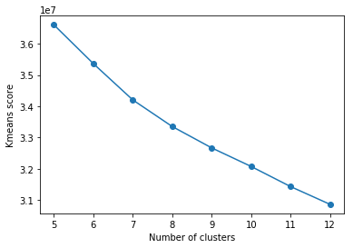

```python
plotKmeansScore(kmeans_scores, list(range(5, 13)))
```

```python
for cluster_number in np.arange(13, 18):
    print('Applying KMeans with {} clusters'.format(cluster_number))
    kmeans = KMeans(n_clusters=cluster_number)
    kmeans.fit(azdias_after_pca)
    average_distance = np.abs(kmeans.score(azdias_after_pca))
    print('KMeans with {} clusters, score = {}'.format(cluster_number, average_distance))
    kmeans_scores.append(average_distance)


# Save the output here, this took 3 hours to run the clustering so I don't want to re-do it
# Applying KMeans with 13 clusters
# KMeans with 13 clusters, score = 30533876.122289788
# Applying KMeans with 14 clusters
# KMeans with 14 clusters, score = 30134085.34972336
# Applying KMeans with 15 clusters
# KMeans with 15 clusters, score = 30166894.887336385
# Applying KMeans with 16 clusters
# KMeans with 16 clusters, score = 29238010.245306067
# Applying KMeans with 17 clusters
# KMeans with 17 clusters, score = 29297516.690929662
```

```
Applying KMeans with 13 clusters
KMeans with 13 clusters, score = 30533876.122289788
Applying KMeans with 14 clusters
KMeans with 14 clusters, score = 30134085.34972336
Applying KMeans with 15 clusters
KMeans with 15 clusters, score = 30166894.887336385
Applying KMeans with 16 clusters
KMeans with 16 clusters, score = 29238010.245306067
Applying KMeans with 17 clusters
KMeans with 17 clusters, score = 29297516.690929662
```

```python
kmeans_scores

# Save the result here, this took 3 hours to run the clustering so I don't want to re-do it
# kmeans_scores = [36607787.4093741,
#  35366940.68327943,
#  34205256.79623956,
#  33353690.484781656,
#  32669600.014807794,
#  32075482.62386631,
#  31431729.1493311,
#  30863625.52688396,
#  30533876.122289788,
#  30134085.34972336,
#  30166894.887336385,
#  29238010.245306067,
#  29297516.690929662]
```

```
[36607787.4093741,
 35366940.68327943,
 34205256.79623956,
 33353690.484781656,
 32669600.014807794,
 32075482.62386631,
 31431729.1493311,
 30863625.52688396,
 30533876.122289788,
 30134085.34972336,
 30166894.887336385,
 29238010.245306067,
 29297516.690929662]
```

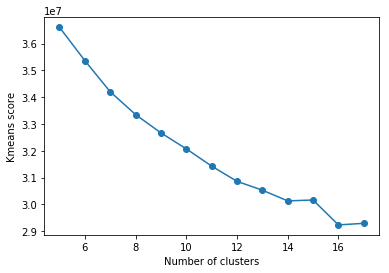

```python
plotKmeansScore(kmeans_scores, list(range(5, 18)))
```

```python
# Re-fit the k-means model with the selected number of clusters and obtain

selected_cluster = 16
print('Applying KMeans with {} clusters'.format(selected_cluster))
kmeans_16 = KMeans(n_clusters=selected_cluster)
kmeans_16.fit(azdias_after_pca)
print('Calculating score...')
average_distance_16 = np.abs(kmeans_16.score(azdias_after_pca))
print('KMeans with {} clusters, score = {}'.format(selected_cluster, average_distance_16))
print('Done')
```

```
Applying KMeans with 16 clusters
Calculating score...
KMeans with 16 clusters, score = 29238001.959705237
Done
```

```python
# cluster predictions for the general population demographics data.

azdias_cluster_predictions = kmeans_16.predict(azdias_after_pca)
azdias_cluster_predictions
```

```
array([15,  9,  7, ..., 14,  4,  3], dtype=int32)
```

### Discussion 3.1: Apply Clustering to General Population

#### Answer

From the above result, it's reasonable to choose k = 16 as the higher number of cluster doesn't give better result, in contrast, it has higher time consumption

### Step 3.2: Apply All Steps to the Customer Data

Now that you have clusters and cluster centers for the general population, it's time to see how the customer data maps on to those clusters. Take care to not confuse this for re-fitting all of the models to the customer data. Instead, you're going to use the fits from the general population to clean, transform, and cluster the customer data. In the last step of the project, you will interpret how the general population fits apply to the customer data.

- Don't forget when loading in the customers data, that it is semicolon (`;`) delimited.
- Apply the same feature wrangling, selection, and engineering steps to the customer demographics using the `clean_data()` function you created earlier. (You can assume that the customer demographics data has similar meaning behind missing data patterns as the general demographics data.)
- Use the sklearn objects from the general demographics data, and apply their transformations to the customers data. That is, you should not be using a `.fit()` or `.fit_transform()` method to re-fit the old objects, nor should you be creating new sklearn objects! Carry the data through the feature scaling, PCA, and clustering steps, obtaining cluster assignments for all of the data in the customer demographics data.

```python
# Load in the customer demographics data.
customers = customers_test # already cleanup above
customers.head()
```

|  | ALTERSKATEGORIE_GROB | ANREDE_KZ | FINANZ_MINIMALIST | FINANZ_SPARER | FINANZ_VORSORGER | FINANZ_ANLEGER | FINANZ_UNAUFFAELLIGER | FINANZ_HAUSBAUER | GREEN_AVANTGARDE | HEALTH_TYP | LP_LEBENSPHASE_FEIN | LP_LEBENSPHASE_GROB | RETOURTYP_BK_S | SEMIO_SOZ | SEMIO_FAM | SEMIO_REL | SEMIO_MAT | SEMIO_VERT | SEMIO_LUST | SEMIO_ERL | SEMIO_KULT | SEMIO_RAT | SEMIO_KRIT | SEMIO_DOM | SEMIO_KAEM | SEMIO_PFLICHT | SEMIO_TRADV | SOHO_KZ | VERS_TYP | … |
| --- | --- | --- | --- | --- | --- | --- | --- | --- | --- | --- | --- | --- | --- | --- | --- | --- | --- | --- | --- | --- | --- | --- | --- | --- | --- | --- | --- | --- | --- | --- |
| 0 | 4.0 | 1 | 5 | 1 | 5 | 1 | 2 | 2 | 1 | 1.0 | 20.0 | 5.0 | 5.0 | 6 | 5 | 2 | 6 | 6 | 7 | 3 | 4 | 1 | 3 | 1 | 1 | 2 | 1 | 0.0 | 1.0 | … |
| 2 | 4.0 | 2 | 5 | 1 | 5 | 1 | 4 | 4 | 1 | 2.0 | 13.0 | 3.0 | 5.0 | 2 | 2 | 1 | 3 | 3 | 7 | 7 | 1 | 2 | 7 | 5 | 6 | 4 | 1 | 0.0 | 2.0 | … |
| 3 | 4.0 | 1 | 5 | 1 | 5 | 2 | 1 | 2 | 0 | 2.0 | NaN | NaN | 3.0 | 6 | 5 | 3 | 4 | 7 | 5 | 3 | 4 | 3 | 3 | 3 | 3 | 3 | 4 | 0.0 | 1.0 | … |
| 4 | 3.0 | 1 | 3 | 1 | 4 | 4 | 5 | 2 | 0 | 3.0 | 31.0 | 10.0 | 5.0 | 4 | 5 | 4 | 6 | 5 | 6 | 4 | 5 | 5 | 3 | 5 | 2 | 5 | 4 | 0.0 | 2.0 | … |
| 5 | 3.0 | 1 | 5 | 1 | 5 | 1 | 2 | 3 | 1 | 3.0 | 17.0 | 5.0 | 3.0 | 6 | 4 | 4 | 1 | 7 | 6 | 4 | 6 | 2 | 5 | 5 | 3 | 3 | 4 | 0.0 | 2.0 | … |

```python
# Apply preprocessing, feature transformation, and clustering from the general
# demographics onto the customer data, obtaining cluster predictions for the
# customer demographics data.

# Process missing data
customers_fullfilled = SimpleImputer().fit_transform(customers)
nan_found = False
for row in customers_fullfilled:
    for val in row:
        if np.isnan(val):
            nan_found = True
            print('Found NAN')
if not nan_found:
    print('All are fullfilled')
```

```
All are fullfilled
```

```python
# Apply feature scaling
cus_scaler = StandardScaler()
print(cus_scaler.get_params())
customers_scaled = pd.DataFrame(cus_scaler.fit_transform(customers_fullfilled))
customers_scaled.columns = customers.columns
customers_scaled.head()
```

```
{'copy': True, 'with_mean': True, 'with_std': True}
```

|  | ALTERSKATEGORIE_GROB | ANREDE_KZ | FINANZ_MINIMALIST | FINANZ_SPARER | FINANZ_VORSORGER | FINANZ_ANLEGER | FINANZ_UNAUFFAELLIGER | FINANZ_HAUSBAUER | GREEN_AVANTGARDE | HEALTH_TYP | LP_LEBENSPHASE_FEIN | LP_LEBENSPHASE_GROB | RETOURTYP_BK_S | SEMIO_SOZ | SEMIO_FAM | SEMIO_REL | SEMIO_MAT | SEMIO_VERT | SEMIO_LUST | SEMIO_ERL | SEMIO_KULT | SEMIO_RAT | SEMIO_KRIT | SEMIO_DOM | SEMIO_KAEM | SEMIO_PFLICHT | SEMIO_TRADV | SOHO_KZ | VERS_TYP | … |
| --- | --- | --- | --- | --- | --- | --- | --- | --- | --- | --- | --- | --- | --- | --- | --- | --- | --- | --- | --- | --- | --- | --- | --- | --- | --- | --- | --- | --- | --- | --- |
| 0 | 0.703047 | -0.702899 | 0.723148 | -0.51697 | 0.516223 | -0.600720 | 0.137509 | -0.553267 | 1.006686 | -1.255575 | -3.616737e-01 | -0.570309 | 0.923249 | 1.032722 | 0.657028 | -0.813825 | 1.267441 | 0.457601 | 0.907437 | -1.067858 | 0.049392 | -1.348202 | -0.514338 | -1.884875 | -1.448583 | -0.719954 | -1.369336 | -0.099689 | -0.994945 | … |
| 1 | 0.703047 | 1.422679 | 0.723148 | -0.51697 | 0.516223 | -0.600720 | 2.181828 | 0.965709 | 1.006686 | 0.049198 | -9.517089e-01 | -1.081181 | 0.923249 | -1.437900 | -1.125323 | -1.498900 | -0.245933 | -1.246148 | 0.907437 | 1.215335 | -1.662252 | -0.634476 | 1.734298 | 0.627872 | 1.339126 | 0.676952 | -1.369336 | -0.099689 | 1.021851 | … |
| 2 | 0.703047 | -0.702899 | 0.723148 | -0.51697 | 0.516223 | 0.396895 | -0.884651 | -0.553267 | -0.993358 | 0.049198 | -2.994609e-16 | 0.000000 | -0.782358 | 1.032722 | 0.657028 | -0.128750 | 0.258525 | 1.025518 | -0.316073 | -1.067858 | 0.049392 | 0.079249 | -0.514338 | -0.628501 | -0.333499 | -0.021501 | 0.785045 | -0.099689 | -0.994945 | … |
| 3 | -0.667985 | -0.702899 | -1.241630 | -0.51697 | -0.665467 | 2.392126 | 3.203988 | -0.553267 | -0.993358 | 1.353971 | 5.655246e-01 | 0.706870 | 0.923249 | -0.202589 | 0.657028 | 0.556326 | 1.267441 | -0.110315 | 0.295682 | -0.497060 | 0.619940 | 1.506700 | -0.514338 | 0.627872 | -0.891041 | 1.375404 | 0.785045 | -0.099689 | 1.021851 | … |
| 4 | -0.667985 | -0.702899 | 0.723148 | -0.51697 | 0.516223 | -0.600720 | 0.137509 | 0.206221 | 1.006686 | 1.353971 | -6.145459e-01 | -0.570309 | -0.782358 | 1.032722 | 0.062911 | 0.556326 | -1.254850 | 1.025518 | 0.295682 | -0.497060 | 1.190488 | -0.634476 | 0.609980 | 0.627872 | -0.333499 | -0.021501 | 0.785045 | -0.099689 | 1.021851 | … |

```python
# Apply feature reduction
cus_pca = PCA()
cus_pca.fit(customers_scaled)

cus_pc_df = pd.DataFrame()
cus_pc_df['#'] = [idx for idx in range(customers_scaled.shape[1])]
cus_pc_df['Component'] = customers_scaled.columns
cus_pc_df['Explained variance'] = cus_pca.explained_variance_
cus_pc_df['Explained variance ratio'] = cus_pca.explained_variance_ratio_
cus_pc_df['Cummulative explained variance'] = cus_pc_df['Explained variance'].cumsum()
cus_pc_df['Cumulative explained variance ratio'] = cus_pc_df['Cummulative explained variance']/sum(cus_pca.explained_variance_)
cus_pc_df.head()
```

|  | # | Component | Explained variance | Explained variance ratio | Cummulative explained variance | Cumulative explained variance ratio |
| --- | --- | --- | --- | --- | --- | --- |
| 0 | 0 | ALTERSKATEGORIE_GROB | 11.247735 | 0.163010 | 11.247735 | 0.163010 |
| 1 | 1 | ANREDE_KZ | 6.526270 | 0.094583 | 17.774005 | 0.257592 |
| 2 | 2 | FINANZ_MINIMALIST | 6.329917 | 0.091737 | 24.103922 | 0.349330 |
| 3 | 3 | FINANZ_SPARER | 4.167085 | 0.060392 | 28.271008 | 0.409722 |
| 4 | 4 | FINANZ_VORSORGER | 2.992370 | 0.043367 | 31.263378 | 0.453089 |

[figure not shown]

```python
fig, (ax1, ax2) = plt.subplots(1, 2, figsize=(20, 10))

ax1.bar(cus_pc_df['Component'], cus_pc_df['Explained variance'])
ax1.set_ylabel('V')
ax1.set_xlabel('C')
ax1.grid()

ax2.plot(cus_pc_df['#'], cus_pc_df['Cumulative explained variance ratio'])
ax2.set_ylabel('CEVR')
ax2.set_xlabel('PCs')
ax2.grid()
```

```python
# from the above plot, select 50 PCs
cus_pca = PCA(n_components=50)
customers_after_pca = cus_pca.fit_transform(customers_scaled)
```

```python
# Get principal components features
cus_pc_feats = []
for pc in range(len(cus_pca.components_)):
    feats = getFeatsForPrincipalComponent(pc, customers_scaled, cus_pca)
    cus_pc_feats.append(feats)
```

```python
# Test some PCs
cus_pc_feats[0]
```

```
FINANZ_HAUSBAUER       0.215118
PLZ8_ANTG3             0.206552
PLZ8_BAUMAX            0.202779
PLZ8_ANTG4             0.195643
HH_EINKOMMEN_SCORE     0.190086
Wealth                 0.182586
ORTSGR_KLS9            0.173183
EWDICHTE               0.172756
KBA05_ANTG4            0.160406
PLZ8_ANTG2             0.158173
INNENSTADT            -0.135586
LP_LEBENSPHASE_GROB   -0.139574
LP_LEBENSPHASE_FEIN   -0.151452
KONSUMNAEHE           -0.152019
PLZ8_GBZ              -0.152404
PLZ8_ANTG1            -0.206978
KBA05_GBZ             -0.207021
KBA05_ANTG1           -0.213319
FINANZ_MINIMALIST     -0.219634
MOBI_REGIO            -0.234449
Name: 0, dtype: float64
```

```python
cus_pc_feats[1]
```

```
FINANZ_ANLEGER           0.293579
Generation               0.259941
FINANZ_SPARER            0.253997
SEMIO_KAEM               0.225968
SEMIO_RAT                0.221921
ANREDE_KZ                0.204595
SEMIO_DOM                0.202970
SEMIO_PFLICHT            0.177655
FINANZ_UNAUFFAELLIGER    0.170987
SEMIO_KRIT               0.169621
SEMIO_SOZ               -0.112784
Movement                -0.113945
GREEN_AVANTGARDE        -0.115368
FINANZ_MINIMALIST       -0.138217
W_KEIT_KIND_HH          -0.141418
RETOURTYP_BK_S          -0.156609
SEMIO_LUST              -0.188010
SEMIO_VERT              -0.213018
ALTERSKATEGORIE_GROB    -0.214599
FINANZ_VORSORGER        -0.247951
Name: 1, dtype: float64
```

```python
cus_pc_feats[-1]
```

```
PLZ8_ANTG3               0.426748
PLZ8_BAUMAX              0.165923
RELAT_AB                 0.109562
KBA05_ANTG1              0.077233
Wealth                   0.070648
REGIOTYP                 0.069890
PLZ8_GBZ                 0.067939
FINANZ_SPARER            0.059650
SEMIO_LUST               0.052206
KBA05_ANTG2              0.047026
FINANZ_UNAUFFAELLIGER   -0.063246
KBA05_GBZ               -0.072410
ALTERSKATEGORIE_GROB    -0.079999
W_KEIT_KIND_HH          -0.090435
FINANZ_MINIMALIST       -0.098308
HH_EINKOMMEN_SCORE      -0.152381
ARBEIT                  -0.162902
PLZ8_ANTG1              -0.348005
PLZ8_ANTG2              -0.449548
PLZ8_ANTG4              -0.561882
Name: 49, dtype: float64
```

```python
# Clustering with 16 clusters
print('Applying KMeans for customers with {} clusters'.format(selected_cluster))
kmeans_16_cus = KMeans(n_clusters=selected_cluster)
kmeans_16_cus.fit(customers_after_pca)
print('Calculating score...')
average_distance_16_cus = np.abs(kmeans_16_cus.score(customers_after_pca))
print('KMeans for customers with {} clusters, score = {}'.format(selected_cluster, average_distance_16_cus))
print('Done')
```

```
Applying KMeans for customers with 16 clusters
Calculating score...
KMeans for customers with 16 clusters, score = 5801983.435706769
Done
```

```python
customers_cluster_predictions = kmeans_16_cus.predict(customers_after_pca)
azdias_cluster_predictions, customers_cluster_predictions
```

```
(array([15,  9,  7, ..., 14,  4,  3], dtype=int32),
 array([ 7,  3, 14, ...,  6,  3,  4], dtype=int32))
```

### Step 3.3: Compare Customer Data to Demographics Data

At this point, you have clustered data based on demographics of the general population of Germany, and seen how the customer data for a mail-order sales company maps onto those demographic clusters. In this final substep, you will compare the two cluster distributions to see where the strongest customer base for the company is.

Consider the proportion of persons in each cluster for the general population, and the proportions for the customers. If we think the company's customer base to be universal, then the cluster assignment proportions should be fairly similar between the two. If there are only particular segments of the population that are interested in the company's products, then we should see a mismatch from one to the other. If there is a higher proportion of persons in a cluster for the customer data compared to the general population (e.g. 5% of persons are assigned to a cluster for the general population, but 15% of the customer data is closest to that cluster's centroid) then that suggests the people in that cluster to be a target audience for the company. On the other hand, the proportion of the data in a cluster being larger in the general population than the customer data (e.g. only 2% of customers closest to a population centroid that captures 6% of the data) suggests that group of persons to be outside of the target demographics.

Take a look at the following points in this step:

- Compute the proportion of data points in each cluster for the general population and the customer data. Visualizations will be useful here: both for the individual dataset proportions, but also to visualize the ratios in cluster representation between groups. Seaborn's [`countplot()`](https://seaborn.pydata.org/generated/seaborn.countplot.html) or [`barplot()`](https://seaborn.pydata.org/generated/seaborn.barplot.html) function could be handy.
  - Recall the analysis you performed in step 1.1.3 of the project, where you separated out certain data points from the dataset if they had more than a specified threshold of missing values. If you found that this group was qualitatively different from the main bulk of the data, you should treat this as an additional data cluster in this analysis. Make sure that you account for the number of data points in this subset, for both the general population and customer datasets, when making your computations!
- Which cluster or clusters are overrepresented in the customer dataset compared to the general population? Select at least one such cluster and infer what kind of people might be represented by that cluster. Use the principal component interpretations from step 2.3 or look at additional components to help you make this inference. Alternatively, you can use the `.inverse_transform()` method of the PCA and StandardScaler objects to transform centroids back to the original data space and interpret the retrieved values directly.
- Perform a similar investigation for the underrepresented clusters. Which cluster or clusters are underrepresented in the customer dataset compared to the general population, and what kinds of people are typified by these clusters?

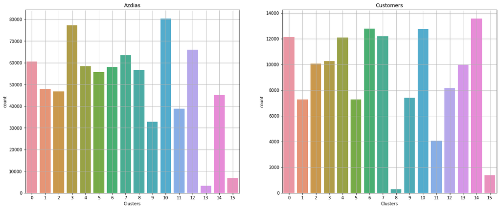

```python
# Compare the proportion of data in each cluster for the customer data to the
# proportion of data in each cluster for the general population.
fig, ax = plt.subplots(1, 2, figsize=(20, 8))
seaborn.countplot(azdias_cluster_predictions, ax=ax[0])
ax[0].set_title('Azdias')
ax[0].set_xlabel('Clusters')
ax[0].grid()

seaborn.countplot(customers_cluster_predictions, ax=ax[1])
ax[1].set_title('Customers')
ax[1].set_xlabel('Clusters')
ax[1].grid()
```

```python
def getClusterPercentage(cluster_predictions):
    cluster_ids, cluster_counts = np.unique(cluster_predictions, return_counts=True)
    total_count = cluster_counts.sum()
    percentages = [int(count / total_count * 100) for count in cluster_counts]
    return percentages

azdias_cluster_percentages = getClusterPercentage(azdias_cluster_predictions)
customers_cluster_percentages = getClusterPercentage(customers_cluster_predictions)
azdias_cluster_percentages, customers_cluster_percentages
```

```
([7, 5, 5, 9, 7, 6, 7, 7, 7, 4, 10, 4, 8, 0, 5, 0],
 [8, 5, 7, 7, 8, 5, 9, 8, 0, 5, 9, 2, 5, 7, 9, 0])
```

```python
presentation_diff = [azdias_cluster_percentages[i] - customers_cluster_percentages[i] for i in range(len(customers_cluster_percentages))]
presentation_diff
```

```
[-1, 0, -2, 2, -1, 1, -2, -1, 7, -1, 1, 2, 3, -7, -4, 0]
```

```python
most_overrepresented_cluster_id = presentation_diff.index(min(presentation_diff))
most_underrepresented_cluster_id = presentation_diff.index(max(presentation_diff))
most_overrepresented_cluster_id, most_underrepresented_cluster_id
```

```
(13, 8)
```

```python
def getPeopleKind(kmeans_model, pca_model, scaler_model, cluster_id, df):
    cluster = kmeans_model.cluster_centers_[cluster_id]
    pca_reverted = pca_model.inverse_transform(cluster)
    scaler_reverted = scaler_model.inverse_transform(pca_reverted)
    result = pd.Series(data = scaler_reverted, index = df.columns)
    return result
```

```python
# What kinds of people are part of a cluster that is overrepresented in the
# customer data compared to the general population?
most_overrepresented_kind = getPeopleKind(kmeans_16, pca, standard_scaler, most_overrepresented_cluster_id, azdias_final)
most_overrepresented_kind
```

```
ALTERSKATEGORIE_GROB        3.091120
ANREDE_KZ                   1.459360
FINANZ_MINIMALIST           3.470122
FINANZ_SPARER               2.135751
FINANZ_VORSORGER            3.860494
FINANZ_ANLEGER              2.190901
FINANZ_UNAUFFAELLIGER       2.340920
FINANZ_HAUSBAUER            3.170510
GREEN_AVANTGARDE            0.651807
HEALTH_TYP                  2.104231
LP_LEBENSPHASE_FEIN        20.199277
LP_LEBENSPHASE_GROB         6.458440
RETOURTYP_BK_S              3.869601
SEMIO_SOZ                   4.248529
SEMIO_FAM                   4.043249
SEMIO_REL                   3.611420
SEMIO_MAT                   3.865133
SEMIO_VERT                  4.587923
SEMIO_LUST                  5.099091
SEMIO_ERL                   4.717133
SEMIO_KULT                  3.841007
SEMIO_RAT                   3.559006
SEMIO_KRIT                  4.419963
SEMIO_DOM                   4.589365
SEMIO_KAEM                  4.148922
SEMIO_PFLICHT               3.642566
SEMIO_TRADV                 3.355411
SOHO_KZ                     0.010742
VERS_TYP                    1.559912
ANZ_PERSONEN                2.148997
ANZ_TITEL                   1.019307
HH_EINKOMMEN_SCORE          3.474142
W_KEIT_KIND_HH              4.380247
WOHNDAUER_2008              8.483517
ANZ_HAUSHALTE_AKTIV        17.472467
ANZ_HH_TITEL                1.816641
KONSUMNAEHE                 2.449061
MIN_GEBAEUDEJAHR         1993.028727
OST_WEST_KZ                 0.795701
WOHNLAGE                    3.525992
```

[output cut: 14 more lines]

```
PLZ8_ANTG1                  2.134028
PLZ8_ANTG2                  2.925296
PLZ8_ANTG3                  1.712014
PLZ8_ANTG4                  0.812387
PLZ8_BAUMAX                 2.213658
PLZ8_HHZ                    3.751633
PLZ8_GBZ                    3.343365
ARBEIT                      3.131228
ORTSGR_KLS9                 5.889535
RELAT_AB                    3.164900
Movement                    0.668909
Generation                 67.408322
Wealth                      2.846422
Lifestage                   3.329390
dtype: float64
```

```python
# What kinds of people are part of a cluster that is underrepresented in the
# customer data compared to the general population?
most_underrepresented_kind = getPeopleKind(kmeans_16, pca, standard_scaler, most_underrepresented_cluster_id, azdias_final)
most_underrepresented_kind
```

```
ALTERSKATEGORIE_GROB        3.289467
ANREDE_KZ                   1.045127
FINANZ_MINIMALIST           4.831154
FINANZ_SPARER               1.601057
FINANZ_VORSORGER            4.211582
FINANZ_ANLEGER              1.472823
FINANZ_UNAUFFAELLIGER       2.197784
FINANZ_HAUSBAUER            1.926763
GREEN_AVANTGARDE            0.966722
HEALTH_TYP                  2.057918
LP_LEBENSPHASE_FEIN        24.773100
LP_LEBENSPHASE_GROB         7.205017
RETOURTYP_BK_S              4.005514
SEMIO_SOZ                   4.854208
SEMIO_FAM                   4.745199
SEMIO_REL                   3.735338
SEMIO_MAT                   3.943714
SEMIO_VERT                  6.260782
SEMIO_LUST                  5.287298
SEMIO_ERL                   3.987365
SEMIO_KULT                  4.900823
SEMIO_RAT                   2.705849
SEMIO_KRIT                  3.128065
SEMIO_DOM                   3.373227
SEMIO_KAEM                  2.594962
SEMIO_PFLICHT               3.121270
SEMIO_TRADV                 3.163551
SOHO_KZ                     0.000001
VERS_TYP                    1.528434
ANZ_PERSONEN                2.234700
ANZ_TITEL                   0.000149
HH_EINKOMMEN_SCORE          2.431491
W_KEIT_KIND_HH              4.027170
WOHNDAUER_2008              8.500593
ANZ_HAUSHALTE_AKTIV         1.970113
ANZ_HH_TITEL                0.005802
KONSUMNAEHE                 3.370162
MIN_GEBAEUDEJAHR         1993.058639
OST_WEST_KZ                 0.896557
WOHNLAGE                    3.075164
```

[output cut: 14 more lines]

```
PLZ8_ANTG1                  2.789204
PLZ8_ANTG2                  2.573292
PLZ8_ANTG3                  1.183101
PLZ8_ANTG4                  0.371943
PLZ8_BAUMAX                 1.249688
PLZ8_HHZ                    3.700139
PLZ8_GBZ                    3.912349
ARBEIT                      3.046051
ORTSGR_KLS9                 5.418583
RELAT_AB                    2.915484
Movement                    0.966406
Generation                 66.170724
Wealth                      2.059040
Lifestage                   3.602452
dtype: float64
```

### Discussion 3.3: Compare Customer Data to Demographics Data

> Congratulations on making it this far in the project! Before you finish, make sure to check through the entire notebook from top to bottom to make sure that your analysis follows a logical flow and all of your findings are documented in **Discussion** cells. Once you've checked over all of your work, you should export the notebook as an HTML document to submit for evaluation. You can do this from the menu, navigating to **File -> Download as -> HTML (.html)**. You will submit both that document and this notebook for your project submission.